# Project - Data Visualisation based on 311 Service Requests, Census Demographics and Crimes in Baltimore

### Problem Statement :

> To find a relationship between the services requested by the population of different age groups in a neighborhood. Also, to find a relationship of crime rates with respect to the services requested. For this, 3 datasets were explored - Census Demographics, Crime by Neighborhood and 311 Customer Service Requests.

### Description:

> We have found the relationship between Services Requested in particular neighborhood and the census demographics. For example, as the population increases, number of service requests also increases. We also evaluated majority of age groups in particular neighborhood and type of requests that were majorly created in that particular area. Also, we found that the method of creating requests varied based on the age group in that particular neighborhood. For example, if a particular neighborhood contains large number of young crowd, it will evidently show large number of internet reported service requests. Also, we related Crime by neighborhood dataset with 311 Service requests by comparing crime rate and the requests rate. This explains the relationship between the number of requests raised and the number of crimes committed in a neighborhood. Another thing that we concluded based on plots is that the areas with higher population shows maximum number of crimes.

### About Datasets

> Here, We are fetching 3 datasets viz- 1) District 311 Service Request dataset present in City service section of Open Baltimore 2) Crime by neighborhood present in Crime section of Open Baltimore 3) Census Neighborhoods dataset found on Data.gov website.(All the columns are similar to Census dataset from Open Baltimore. But the neighborhood values from 311 Service requests and Crime did not match. Therefore, chosen to use it from Data.gov)

> Service Type tells you about the type of issue that is raised, for example, housing and community development (HCD), transportation roadway maintenance (e.g. fixing potholes), etc. Method Received tells us about the mode of communicating the request. It can be Phone, API or Internal. Some important dates in context of Service requests are also provided like Due date, created date and Status date. Also the timestamp of the last activity that is performed for the particular request is also mentioned.

> Census by Neighborhood dataset consists of Neighborhood, total population in that neighborhood, total female and male population, percentage of population in different age groups like 0-4,5-11,65 above, etc.

> Crime dataset consists of crime date, crime code which states the type of crime that is committed, neighborhood where the crime was committed, location states actual location of crime, description describes the crime, weapon that was used and district.

### How is it useful?

> - The data consists of details about every phone call, query, complaint and request addressed by the 311 system adopted by Baltimore government. This dataset is useful to address how the service requests were handled by government workers and the type of problems that bothered Baltimore citizens the most.
> - Crime dataset and census demographics dataset gives the overall information about the crimes and population in baltimore. Census demographic dataset will be very useful to check what is the majority age group in particular neighborhood of baltimore. Crimes gives idea about the type of crimes and the details about the type of crime in every neighborhood of baltimore.

### 1. Initially import all the required libraries

```python
import pandas as pd
import matplotlib.pyplot as plt
import numpy as np
import datetime
```

### 2. Now fetch the dataset downloaded from Open Baltimore website

```python
df = pd.read_csv("D:\MS CS Sem 1\DS\Assignment 1\Dbs\District_4_311_Service_Requests.csv")
```

```python
df2 = pd.read_csv("D:\MS CS Sem 1\DS\Project\Dataset\Census_Neighborhoods.csv", low_memory = False)
```

```python
df3 = pd.read_csv("D:\MS CS Sem 1\DS\Project\Dataset\Crime_By_Neighborhood.csv")
```

```python
df.shape
```

```
(20685, 13)
```

```python
df2.shape
```

```
(278, 37)
```

```python
df3.shape
```

```
(49559, 7)
```

### Drawing connections between three datasets:

> **The essence of our connections between three datasets lies in 'Neighborhood' column. All the three datasets i.e. Crime by neighborhood, Census Demographics and 311 service requests revolves around neighborhood. So based on this field, we were able to merge all the datasets. This was also a reason why we could find out the relationships between them.**

> ### Why was this a good idea?

> **Since the crimes can be compared with service requests, service requests can be compared with both Crimes and Population and Population can be compared with Crimes using neighborhood, we thought this was a good choice.**

### 3. Checking all the columns available and selecting few amongst them

```python
df.columns
```

```
Index(['ServiceRequestNum', 'SRType', 'Neighborhood', 'Address', 'ZipCode',
       'MethodReceived', 'CreatedDate', 'DueDate', 'StatusDate', 'SRStatus',
       'LastActivity', 'Outcome', 'LastActivityDate'],
      dtype='object')
```

```python
df_service = df[['ServiceRequestNum','SRType','MethodReceived','CreatedDate','StatusDate','DueDate','LastActivityDate','Neighborhood']]
```

```python
df_census = df2.reindex(columns=['Name','Population','Male','Female','AGE0_4','AGE5_11','AGE12_14','AGE15_17','AGE18_24','AGE25_34','AGE35_44','AGE45_64','AGE65ovr'])
```

```python
df_census = df_census.rename(columns={"Name":"Neighborhood"})
```

### 4. Now let's fetch first few records of both the datasets.

```python
df_service.head()
```

|  | ServiceRequestNum | SRType | MethodReceived | CreatedDate | StatusDate | DueDate | LastActivityDate | Neighborhood |
| --- | --- | --- | --- | --- | --- | --- | --- | --- |
| 0 | 15-00000620 | BGE-StLight(s) Out | API | 1/1/2015 17:45 | 1/2/2015 | 1/5/2015 | NaN | Radnor-Winston |
| 1 | 15-00000187 | TRS-Abandoned Vehicle | Phone | 1/1/2015 10:25 | 1/8/2015 | 1/6/2015 | NaN | Chinquapin Park |
| 2 | 15-00000217 | TRM-Pothole Repair | API | 1/1/2015 10:54 | 1/2/2015 | 1/3/2015 | 1/2/2015 | Chinquapin Park |
| 3 | 15-00000236 | BGE-StLight(s) Out | Phone | 1/1/2015 11:09 | 1/2/2015 | 1/5/2015 | NaN | Glen Oaks |
| 4 | 15-00000241 | BGE-StLight(s) Out | Phone | 1/1/2015 11:14 | 1/2/2015 | 1/5/2015 | NaN | Woodbourne Heights |

```python
df_census.head()
```

|  | Neighborhood | Population | Male | Female | AGE0_4 | AGE5_11 | AGE12_14 | AGE15_17 | AGE18_24 | AGE25_34 | AGE35_44 | AGE45_64 | AGE65ovr |
| --- | --- | --- | --- | --- | --- | --- | --- | --- | --- | --- | --- | --- | --- |
| 0 | Abell | 889.0 | 424.0 | 465.0 | 55.0 | 43.0 | 5.0 | 10.0 | 118.0 | 254.0 | 149.0 | 186.0 | 69.0 |
| 1 | Allendale | 3554.0 | 1536.0 | 2018.0 | 179.0 | 315.0 | 136.0 | 181.0 | 317.0 | 383.0 | 315.0 | 1039.0 | 689.0 |
| 2 | Arcadia | 1235.0 | 592.0 | 643.0 | 101.0 | 85.0 | 40.0 | 55.0 | 116.0 | 188.0 | 164.0 | 380.0 | 106.0 |
| 3 | Boyd-Booth | 822.0 | 408.0 | 414.0 | 60.0 | 94.0 | 26.0 | 40.0 | 98.0 | 106.0 | 89.0 | 232.0 | 77.0 |
| 4 | Arlington | 2598.0 | 1219.0 | 1379.0 | 148.0 | 237.0 | 92.0 | 114.0 | 231.0 | 297.0 | 305.0 | 775.0 | 399.0 |

```python
df3.head()
```

|  | CrimeDate | CrimeCode | Location | Description | Weapon | District | Neighborhood |
| --- | --- | --- | --- | --- | --- | --- | --- |
| 0 | 1/1/2012 | 4A | 500 CHATEAU AV | AGG. ASSAULT | FIREARM | NORTHERN | Winston-Govans |
| 1 | 1/1/2012 | 4E | 2200 W NORTH AV | COMMON ASSAULT | HANDS | WESTERN | Coppin Heights/Ash-Co-Eas |
| 2 | 1/1/2012 | 4E | 0 S LINWOOD AV | COMMON ASSAULT | HANDS | SOUTHEASTERN | Patterson Park Neighborho |
| 3 | 1/1/2012 | 6D | 5600 LOCH RAVEN BD | LARCENY FROM AUTO | NaN | NORTHEASTERN | Loch Raven |
| 4 | 1/1/2012 | 6D | 6300 PIONEER DR | LARCENY FROM AUTO | NaN | NORTHEASTERN | Hamilton Hills |

### 5. Working with missing values in datasets:

Drop the null values present in Service and Crime dataset. Also, we deleted null values in Services. The reason for deleting these values was that, it might impact the results that we concluded.

```python
len(df_service)
```

```
20685
```

```python
df_service = df_service.dropna()
```

```python
len(df_service)
```

```
14943
```

```python
df_crime = df3.dropna()
len(df_crime)
```

```
17141
```

```python
df_crime
```

|  | CrimeDate | CrimeCode | Location | Description | Weapon | District | Neighborhood |
| --- | --- | --- | --- | --- | --- | --- | --- |
| 0 | 1/1/2012 | 4A | 500 CHATEAU AV | AGG. ASSAULT | FIREARM | NORTHERN | Winston-Govans |
| 1 | 1/1/2012 | 4E | 2200 W NORTH AV | COMMON ASSAULT | HANDS | WESTERN | Coppin Heights/Ash-Co-Eas |
| 2 | 1/1/2012 | 4E | 0 S LINWOOD AV | COMMON ASSAULT | HANDS | SOUTHEASTERN | Patterson Park Neighborho |
| 6 | 1/1/2012 | 4E | 500 N GLOVER ST | COMMON ASSAULT | HANDS | SOUTHEASTERN | McElderry Park |
| 7 | 1/1/2012 | 4E | 4900 GOODNOW RD | COMMON ASSAULT | HANDS | NORTHEASTERN | Frankford |
| 11 | 1/1/2012 | 4C | 500 LONEYS LA | AGG. ASSAULT | OTHER | SOUTHEASTERN | Ellwood Park/Monument |
| 12 | 1/1/2012 | 4E | 1500 GORSUCH AV | COMMON ASSAULT | HANDS | NORTHEASTERN | Coldstream Homestead Mont |
| 14 | 1/1/2012 | 4C | 400 E BALTIMORE ST | AGG. ASSAULT | OTHER | CENTRAL | Downtown |
| 18 | 1/1/2012 | 4E | 300 N HIGHLAND AV | COMMON ASSAULT | HANDS | SOUTHEASTERN | Baltimore Highlands |
| 20 | 1/1/2012 | 4C | 2000 GRINNALDS AV | AGG. ASSAULT | OTHER | SOUTHWESTERN | Morrell Park |
| 21 | 1/1/2012 | 4E | 500 N ELLWOOD AV | COMMON ASSAULT | HANDS | SOUTHEASTERN | Ellwood Park/Monument |
| 27 | 1/1/2012 | 4B | 1900 E NORTH AV | AGG. ASSAULT | KNIFE | EASTERN | South Clifton Park |
| 28 | 1/1/2012 | 3CF | 1800 RUSSELL ST | ROBBERY - COMMERCIAL | FIREARM | SOUTHERN | Carroll - Camden Industri |
| 34 | 1/1/2012 | 4C | 0 E RANDALL ST | AGG. ASSAULT | OTHER | SOUTHERN | South Baltimore |
| 36 | 1/1/2012 | 4E | 1000 N WOLFE ST | COMMON ASSAULT | HANDS | EASTERN | Middle East |
| 37 | 1/1/2012 | 4E | 1000 N WOLFE ST | COMMON ASSAULT | HANDS | EASTERN | Middle East |
| 38 | 1/1/2012 | 4E | 2800 CARVER RD | COMMON ASSAULT | HANDS | SOUTHERN | Cherry Hill |
| 41 | 1/1/2012 | 9S | 500 OAKLAND AV | SHOOTING | FIREARM | NORTHERN | Wilson Park |
| 42 | 1/1/2012 | 4A | 500 OAKLAND AVE | AGG. ASSAULT | FIREARM | NORTHERN | Wilson Park |
| 45 | 1/1/2012 | 4E | 400 N ROSE ST | COMMON ASSAULT | HANDS | SOUTHEASTERN | McElderry Park |
| 46 | 1/1/2012 | 4C | 5700 PLAINFIELD AV | AGG. ASSAULT | OTHER | NORTHEASTERN | Frankford |
| 48 | 1/1/2012 | 4C | 2100 BAKER ST | AGG. ASSAULT | OTHER | WESTERN | Easterwood |
| 50 | 1/1/2012 | 4E | 2600 GREENMOUNT AV | COMMON ASSAULT | HANDS | NORTHERN | Harwood |
| 52 | 1/1/2012 | 4E | 1800 W LAFAYETTE AV | COMMON ASSAULT | HANDS | WESTERN | Sandtown-Winchester |
| 61 | 1/1/2012 | 3JF | 700 N FULTON AV | ROBBERY - RESIDENCE | FIREARM | WESTERN | Harlem Park |
| 64 | 1/1/2012 | 4C | 400 BOULDIN ST | AGG. ASSAULT | OTHER | SOUTHEASTERN | Ellwood Park/Monument |
| 65 | 1/1/2012 | 4E | 0 N GAY ST | COMMON ASSAULT | HANDS | CENTRAL | Downtown |
| 66 | 1/1/2012 | 4E | 4000 EIERMAN AV | COMMON ASSAULT | HANDS | NORTHEASTERN | Arcadia |
| 67 | 1/1/2012 | 4E | 1100 KEVIN RD | COMMON ASSAULT | HANDS | SOUTHWESTERN | Rognel Heights |
| 69 | 1/1/2012 | 4E | 800 BETHUNE RD | COMMON ASSAULT | HANDS | SOUTHERN | Cherry Hill |
| ... | ... | ... | ... | ... | ... | ... | ... |
| 49462 | 12/31/2012 | 3AF | 3700 ELLERSLIE AV | ROBBERY - STREET | FIREARM | NORTHERN | Waverly |
| 49463 | 12/31/2012 | 3AF | 3700 ELLERSLIE AV | ROBBERY - STREET | FIREARM | NORTHERN | Waverly |
| 49467 | 12/31/2012 | 4E | 2400 FREDERICK AV | COMMON ASSAULT | HANDS | SOUTHWESTERN | Shipley Hill |
| 49468 | 12/31/2012 | 3AK | 0 E HENRIETTA ST | ROBBERY - STREET | KNIFE | SOUTHERN | Federal Hill |
| 49474 | 12/31/2012 | 4E | 800 PARK AV | COMMON ASSAULT | HANDS | CENTRAL | Mount Vernon |
| 49475 | 12/31/2012 | 3CF | 4100 NORFOLK AV | ROBBERY - COMMERCIAL | FIREARM | NORTHWESTERN | West Forest Park |
| 49481 | 12/31/2012 | 1F | 2100 BRYANT AV | HOMICIDE | FIREARM | WESTERN | Mondawmin |
| 49483 | 12/31/2012 | 4E | 1300 HARLEM AV | COMMON ASSAULT | HANDS | WESTERN | Harlem Park |
| 49488 | 12/31/2012 | 4E | 200 N HOWARD ST | COMMON ASSAULT | HANDS | CENTRAL | Downtown |
| 49490 | 12/31/2012 | 4E | 1200 ROSSITER AV | COMMON ASSAULT | HANDS | NORTHEASTERN | New Northwood |
| 49491 | 12/31/2012 | 4C | 0 S ABINGTON AV | AGG. ASSAULT | OTHER | SOUTHWESTERN | Carroll-South Hilton |
| 49492 | 12/31/2012 | 4C | 2600 MARBOURNE AV | AGG. ASSAULT | OTHER | SOUTHERN | Lakeland |
| 49496 | 12/31/2012 | 4A | 5600 WINNER AV | AGG. ASSAULT | FIREARM | NORTHWESTERN | Glen |
| 49501 | 12/31/2012 | 4E | 300 S PULASKI ST | COMMON ASSAULT | HANDS | SOUTHWESTERN | Carrollton Ridge |
| 49503 | 12/31/2012 | 4E | 1200 LINWOOD AVE | COMMON ASSAULT | HANDS | EASTERN | Berea |
| 49504 | 12/31/2012 | 4E | 300 STOCKHOLM ST | COMMON ASSAULT | HANDS | SOUTHERN | Carroll - Camden Industri |
| 49505 | 12/31/2012 | 4E | 300 STOCKHOLM ST | COMMON ASSAULT | HANDS | SOUTHERN | Carroll - Camden Industri |
| 49509 | 12/31/2012 | 4E | 5100 GOODNOW RD | COMMON ASSAULT | HANDS | NORTHEASTERN | Frankford |
| 49519 | 12/31/2012 | 4C | 200 MONTFORD AVE | AGG. ASSAULT | OTHER | SOUTHEASTERN | Patterson Place |
| 49520 | 12/31/2012 | 4E | 4900 MIDWOOD AV | COMMON ASSAULT | HANDS | NORTHERN | Kenilworth Park |
| 49521 | 12/31/2012 | 4E | 900 DANTREY CT | COMMON ASSAULT | HANDS | SOUTHERN | Brooklyn |
| 49522 | 12/31/2012 | 4E | 900 DANTREY CT | COMMON ASSAULT | HANDS | SOUTHERN | Brooklyn |
| 49528 | 12/31/2012 | 4E | 2000 WILKINS AVE | COMMON ASSAULT | HANDS | SOUTHERN | Carrollton Ridge |
| 49535 | 12/31/2012 | 4E | 2000 WILKENS AV | COMMON ASSAULT | HANDS | SOUTHERN | Carrollton Ridge |
| 49539 | 12/31/2012 | 4E | 2800 HINSDALE DR | COMMON ASSAULT | HANDS | SOUTHERN | Lakeland |
| 49540 | 12/31/2012 | 4E | 3500 CHESTERFIELD AV | COMMON ASSAULT | HANDS | NORTHEASTERN | Belair-Edison |
| 49544 | 12/31/2012 | 3AF | 6000 NORTHWOOD DR | ROBBERY - STREET | FIREARM | NORTHERN | Evesham Park |
| 49545 | 12/31/2012 | 3AF | 3800 W FOREST PARK AV | ROBBERY - STREET | FIREARM | NORTHWESTERN | Central Forest Park |
| 49546 | 12/31/2012 | 4B | 1000 CATHEDRAL ST | AGG. ASSAULT | KNIFE | CENTRAL | Mid-Town Belvedere |
| 49551 | 12/31/2012 | 4E | 200 S DALLAS CT | COMMON ASSAULT | HANDS | SOUTHEASTERN | Perkins Homes |

17141 rows × 7 columns

Creating a copy of census dataframe. Deleting the rows where Population is equal to zero.Population in any of the neighborhood can not be equal to zero. Such values from the dataset must thus be removed.

```python
df_census1 = df_census
columns=['Population']
len(df_census1)
```

```
278
```

```python
df_census1 = df_census1.replace(0, pd.np.nan).dropna(axis=0, how='any', subset=columns).fillna(0)
```

```python
len(df_census1)
```

```
256
```

## 6. Computing new column using existing columns to derive useful information

##### Since the request created date and Date of the last activity performed is present in the above dataset, We'll calculate the number of days required to resolve each request. We'll assign 'Number of Days' to dataframe as a new column

##### Also, Young Citizens column will be created using addition of columns upto 35-44 age groups.

##### Similarly, senior Citizen column is created using addition of columns having age group higher that 44.

```python
import datetime
df_service.LastActivityDate = pd.to_datetime(df_service.LastActivityDate)
df_service.DueDate = pd.to_datetime(df_service.DueDate)
df_service.CreatedDate = pd.to_datetime(df_service.CreatedDate)

df_service = df_service.assign(DaysRequired = df_service.LastActivityDate - df_service.CreatedDate + datetime.timedelta(days=1))
```

```python
df_service.columns
```

```
Index(['ServiceRequestNum', 'SRType', 'MethodReceived', 'CreatedDate',
       'StatusDate', 'DueDate', 'LastActivityDate', 'Neighborhood',
       'DaysRequired'],
      dtype='object')
```

```python
df_census1['Young_citizens'] = df_census1['AGE0_4'] + df_census1['AGE5_11'] + df_census1['AGE12_14'] + df_census1['AGE15_17'] + df_census1['AGE18_24'] + df_census1['AGE25_34'] + df_census1['AGE35_44']
```

```python
df_census1['Senior_citizens'] = df_census1['AGE45_64'] + df_census1['AGE65ovr']
```

### 7. Processing of the columns values

##### I'll change the data type of 'Number of columns' to only 'Days', since I'am interested to know only the number of days for plotting the graph

```python
df_service.DaysRequired = pd.to_timedelta(df_service.DaysRequired,unit='d').astype('timedelta64[D]')
df_service.DaysRequired.head()
df_service.head()
```

|  | ServiceRequestNum | SRType | MethodReceived | CreatedDate | StatusDate | DueDate | LastActivityDate | Neighborhood | DaysRequired |
| --- | --- | --- | --- | --- | --- | --- | --- | --- | --- |
| 2 | 15-00000217 | TRM-Pothole Repair | API | 2015-01-01 10:54:00 | 1/2/2015 | 2015-01-03 | 2015-01-02 | Chinquapin Park | 1.0 |
| 5 | 15-00000412 | SW-Dirty Alley | Phone | 2015-01-01 13:09:00 | 1/5/2015 | 2015-01-08 | 2015-01-05 | Ramblewood | 4.0 |
| 13 | 15-00001181 | SW-Dirty Street | Phone | 2015-01-02 09:05:00 | 1/5/2015 | 2015-01-09 | 2015-01-05 | Loch Raven | 3.0 |
| 16 | 15-00002685 | TRM-Pickup Pothole | Internal | 2015-01-02 14:31:00 | 1/2/2015 | 2015-01-02 | 2015-01-02 | New Northwood | 0.0 |
| 17 | 15-00002689 | TRM-Pickup Pothole | Internal | 2015-01-02 14:33:00 | 1/2/2015 | 2015-01-02 | 2015-01-02 | New Northwood | 0.0 |

### 8. Based on Method via which the request was received (Method Received column)

The pie chart below shows that the maximum requests in baltimore neighborhoods were sent via phone calls whereas only single request was raised via Email.

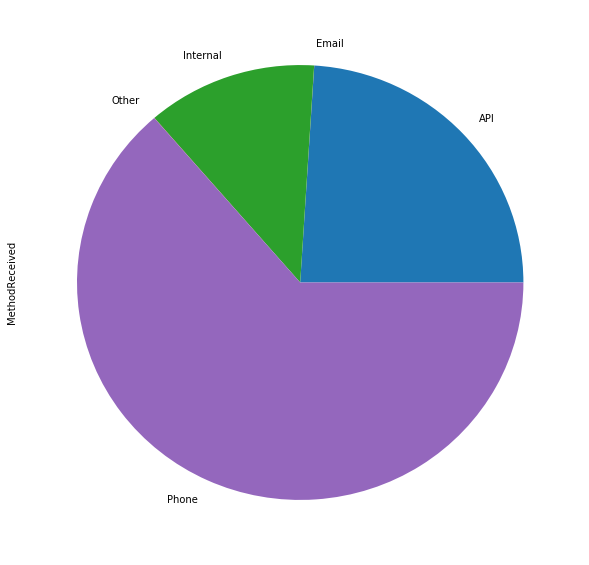

```python
fig, ax = plt.subplots(figsize=(10,10))
AverageNumberOfDays = df_service.groupby('MethodReceived')['MethodReceived'].count().plot.pie(subplots=True)
```

### 9. Find relationship between population and number of service request using 311 service request and Census Demographic datasets

Merging the Neighborhood and services from Services dataset and Population from Census demographic dataset for displaying the relationship between them.

```python
df_service1 = df_service.groupby(["Neighborhood"]).size()
```

```python
df_services = pd.Series.to_frame(df_service1)
df_census2 = df_census1[['Neighborhood','Population']]
```

```python
df_merged = pd.merge(df_census2,df_services, on='Neighborhood')
```

```python
df_merged = df_merged.rename(columns={0:"Services"})
```

```python
df_merged.head()
```

|  | Neighborhood | Population | Services |
| --- | --- | --- | --- |
| 0 | Bellona-Gittings | 599.0 | 162 |
| 1 | Cameron Village | 1435.0 | 648 |
| 2 | Cedarcroft | 726.0 | 200 |
| 3 | Chinquapin Park | 1309.0 | 573 |
| 4 | Loch Raven | 6163.0 | 1604 |

Since the String values can not be plotted on 3D graph, we converted the values to numeric form. These numeric values will thus be used to plot graphs.

```python
neighborhood_num = {"Neighborhood": {"Bellona-Gittings":1,
"Cameron Village":2,
"Cedarcroft":3,
"Chinquapin Park":4,
"Loch Raven":5,
"Glen Oaks":6,
"Guilford":7,
"Homeland":8,
"Idlewood":9,
"Kenilworth Park":10,
"Kernewood":11,
"Lake Evesham":12,
"Lake Walker":13,
"Loyola/Notre Dame":14,
"Mid-Govans":15,
"New Northwood":16,
"Pen Lucy":17,
"Radnor-Winston":18,
"Ramblewood":19,
"Richnor Springs":20,
"Rosebank":21,
"Villages Of Homeland":22,
"Woodbourne Heights":23,
"Wilson Park":24,
"Evesham Park":25,
"Belvedere":26,
"York-Homeland":27}}
```

```python
df_merged.replace(neighborhood_num, inplace = True)
```

```python
df_merged.Neighborhood
```

```
0      1
1      2
2      3
3      4
4      5
5      6
6      7
7      8
8      9
9     10
10    11
11    12
12    13
13    14
14    15
15    16
16    17
17    18
18    19
19    20
20    21
21    22
22    23
23    24
24    25
25    26
26    27
Name: Neighborhood, dtype: int64
```

```python
df_merged.Population
```

```
0      599.0000
1     1435.0000
2      726.0000
3     1309.0000
4     6163.0000
5     2887.0000
6     2214.0000
7     3201.0000
8     2676.0000
9     1206.0000
10     726.0000
11     543.0000
12    2095.0000
13    3208.0000
14    1465.0000
15    4972.0000
16    3078.0000
17     684.0000
18    1705.0000
19     676.0000
20     394.0000
21     562.3255
22    1795.0000
23     632.3202
24     709.0000
25     720.0000
26     482.6745
Name: Population, dtype: float64
```

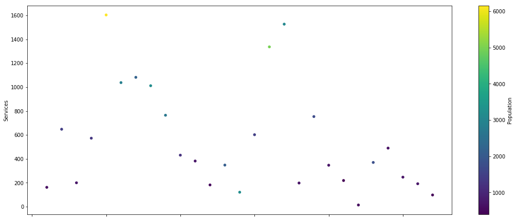

```python
ax2  = df_merged.plot.scatter(x='Neighborhood',
                              y='Services',
                              c='Population',
                              colormap='viridis',
                              figsize=(18.5,7.5))
```

###### Plotting the 2D graph of Services vs Population shows that the Number of Service request for any given neighborhood in Baltimore are directly proportional to the total population in that particular area. There are negligible outliers which can be ignored.

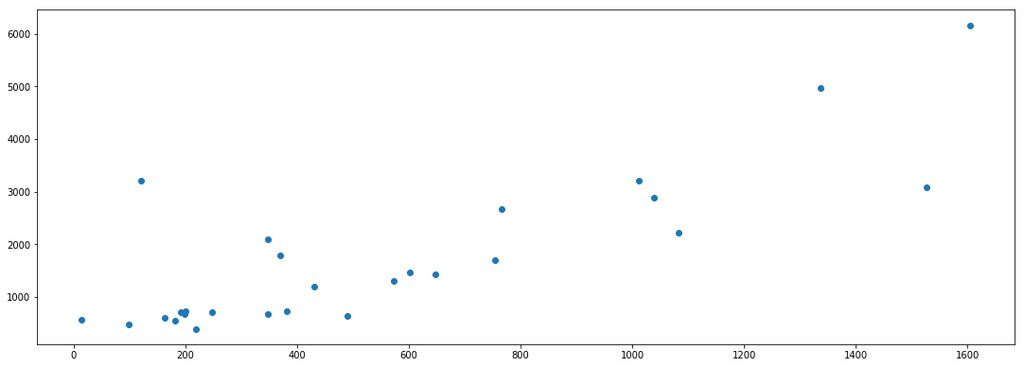

```python
plt.figure(figsize=(18.5,6.5))
plt.scatter(df_merged['Services'], df_merged['Population'])
plt.show()
```

### 10. Plot relationship between majority of age groups and method of raising the service request.

```python
df_census1.columns
```

```
Index(['Neighborhood', 'Population', 'Male', 'Female', 'AGE0_4', 'AGE5_11',
       'AGE12_14', 'AGE15_17', 'AGE18_24', 'AGE25_34', 'AGE35_44', 'AGE45_64',
       'AGE65ovr', 'Young_citizens', 'Senior_citizens'],
      dtype='object')
```

```python
df_cen_sorted = df_census1.sort_values(by=['Young_citizens'])
df_cen_sorted.head()
```

|  | Neighborhood | Population | Male | Female | AGE0_4 | AGE5_11 | AGE12_14 | AGE15_17 | AGE18_24 | AGE25_34 | AGE35_44 | AGE45_64 | AGE65ovr | Young_citizens | Senior_citizens |
| --- | --- | --- | --- | --- | --- | --- | --- | --- | --- | --- | --- | --- | --- | --- | --- |
| 122 | Johns Hopkins Homewood | 18.0 | 8.0 | 10.0 | 4.0 | 0.0 | 0.0 | 0.0 | 1.0 | 8.0 | 4.0 | 1.0 | 0.0 | 17.0 | 1.0 |
| 19 | Blythewood | 72.0 | 38.0 | 34.0 | 2.0 | 12.0 | 2.0 | 5.0 | 1.0 | 2.0 | 12.0 | 20.0 | 16.0 | 36.0 | 36.0 |
| 116 | Hopkins Bayview | 103.0 | 46.0 | 57.0 | 2.0 | 3.0 | 1.0 | 2.0 | 2.0 | 17.0 | 12.0 | 20.0 | 44.0 | 39.0 | 64.0 |
| 50 | Dickeyville | 156.0 | 73.0 | 83.0 | 12.0 | 5.0 | 0.0 | 1.0 | 3.0 | 15.0 | 19.0 | 67.0 | 34.0 | 55.0 | 101.0 |
| 171 | Saint Paul | 107.0 | 55.0 | 52.0 | 9.0 | 14.0 | 5.0 | 3.0 | 8.0 | 19.0 | 16.0 | 24.0 | 9.0 | 74.0 | 33.0 |

```python
df_cen_sorted.tail()
```

|  | Neighborhood | Population | Male | Female | AGE0_4 | AGE5_11 | AGE12_14 | AGE15_17 | AGE18_24 | AGE25_34 | AGE35_44 | AGE45_64 | AGE65ovr | Young_citizens | Senior_citizens |
| --- | --- | --- | --- | --- | --- | --- | --- | --- | --- | --- | --- | --- | --- | --- | --- |
| 25 | Brooklyn | 9996.0 | 4870.0 | 5126.0 | 1055.0 | 1163.0 | 378.0 | 390.0 | 1132.0 | 1740.0 | 1237.0 | 2242.0 | 659.0 | 7095.0 | 2901.0 |
| 276 | Charles Village | 8906.0 | 4676.0 | 4230.0 | 146.0 | 58.0 | 26.0 | 47.0 | 4562.0 | 1792.0 | 731.0 | 1087.0 | 457.0 | 7362.0 | 1544.0 |
| 29 | Canton | 12192.0 | 6017.0 | 6175.0 | 512.0 | 232.0 | 80.0 | 88.0 | 1253.0 | 4835.0 | 1738.0 | 2192.0 | 1262.0 | 8738.0 | 3454.0 |
| 274 | Belair-Edison | 16690.0 | 7500.0 | 9190.0 | 1134.0 | 1734.0 | 794.0 | 873.0 | 1825.0 | 2251.0 | 2145.0 | 4675.0 | 1259.0 | 10756.0 | 5934.0 |
| 45 | Frankford | 17694.0 | 8056.0 | 9638.0 | 1383.0 | 1708.0 | 654.0 | 748.0 | 2180.0 | 2672.0 | 2269.0 | 4617.0 | 1463.0 | 11614.0 | 6080.0 |

```python
df_service.loc[df_service['Neighborhood'] == 'Chinquapin Park'].groupby('MethodReceived').size()
```

```
MethodReceived
API          92
Internal     82
Phone       399
dtype: int64
```

```python
neighborhood = df_merged['Neighborhood']
neighborhood = pd.Series.to_frame(neighborhood)
print(neighborhood)
```

```
    Neighborhood
0              1
1              2
2              3
3              4
4              5
5              6
6              7
7              8
8              9
9             10
10            11
11            12
12            13
13            14
14            15
15            16
16            17
17            18
18            19
19            20
20            21
21            22
22            23
23            24
24            25
25            26
26            27
```

```python
df12 = df_service[['Neighborhood','MethodReceived']]
df12 = df12.sort_values(by=['Neighborhood'])
df12
```

|  | Neighborhood | MethodReceived |
| --- | --- | --- |
| 18002 | Bellona-Gittings | Internal |
| 18914 | Bellona-Gittings | Phone |
| 3143 | Bellona-Gittings | API |
| 6367 | Bellona-Gittings | API |
| 3175 | Bellona-Gittings | API |
| 17561 | Bellona-Gittings | API |
| 12066 | Bellona-Gittings | API |
| 12086 | Bellona-Gittings | API |
| 14089 | Bellona-Gittings | API |
| 14070 | Bellona-Gittings | Phone |
| 3251 | Bellona-Gittings | API |
| 5415 | Bellona-Gittings | API |
| 8999 | Bellona-Gittings | Phone |
| 8932 | Bellona-Gittings | Phone |
| 8905 | Bellona-Gittings | Phone |
| 19085 | Bellona-Gittings | Phone |
| 14017 | Bellona-Gittings | API |
| 8830 | Bellona-Gittings | Phone |
| 5637 | Bellona-Gittings | API |
| 8765 | Bellona-Gittings | Phone |
| 17380 | Bellona-Gittings | API |
| 5684 | Bellona-Gittings | API |
| 5690 | Bellona-Gittings | Phone |
| 19074 | Bellona-Gittings | API |
| 5695 | Bellona-Gittings | Internal |
| 5413 | Bellona-Gittings | API |
| 5411 | Bellona-Gittings | API |
| 11423 | Bellona-Gittings | API |
| 11424 | Bellona-Gittings | API |
| 18684 | Bellona-Gittings | API |
| ... | ... | ... |
| 16070 | York-Homeland | Phone |
| 5553 | York-Homeland | Internal |
| 1319 | York-Homeland | Phone |
| 4250 | York-Homeland | Internal |
| 7666 | York-Homeland | Phone |
| 10217 | York-Homeland | Phone |
| 481 | York-Homeland | Phone |
| 14879 | York-Homeland | API |
| 20241 | York-Homeland | Phone |
| 10975 | York-Homeland | Internal |
| 4354 | York-Homeland | Phone |
| 10976 | York-Homeland | Internal |
| 2836 | York-Homeland | Phone |
| 13839 | York-Homeland | API |
| 6106 | York-Homeland | Phone |
| 11658 | York-Homeland | API |
| 17935 | York-Homeland | API |
| 19076 | York-Homeland | API |
| 4416 | York-Homeland | Internal |
| 7259 | York-Homeland | Internal |
| 72 | York-Homeland | Internal |
| 19881 | York-Homeland | Phone |
| 15071 | York-Homeland | Phone |
| 3770 | York-Homeland | API |
| 4173 | York-Homeland | Internal |
| 11866 | York-Homeland | Phone |
| 13804 | York-Homeland | API |
| 5316 | York-Homeland | Phone |
| 17934 | York-Homeland | Phone |
| 14335 | York-Homeland | Phone |

14943 rows × 2 columns

```python
api = df_service[ (df_service.MethodReceived == 'API') | (df_service.MethodReceived == 'API')]
api = api.groupby('Neighborhood').size()
api = pd.Series.to_frame(api)
api_sorted = api.sort_values(by=['Neighborhood'])
api_sorted = api_sorted.rename(columns={0:"Api_count"})
type(api_sorted)
```

```
pandas.core.frame.DataFrame
```

```python
df_cen_api = pd.merge(df_cen_sorted,api_sorted, on='Neighborhood')
df_cen_api
```

|  | Neighborhood | Population | Male | Female | AGE0_4 | AGE5_11 | AGE12_14 | AGE15_17 | AGE18_24 | AGE25_34 | AGE35_44 | AGE45_64 | AGE65ovr | Young_citizens | Senior_citizens | Api_count |
| --- | --- | --- | --- | --- | --- | --- | --- | --- | --- | --- | --- | --- | --- | --- | --- | --- |
| 0 | York-Homeland | 482.6745 | 204.898 | 277.7765 | 17.2415 | 24.2415 | 5.4765 | 4.9530 | 83.334 | 40.3955 | 47.6775 | 129.8250 | 129.5300 | 223.3195 | 259.3550 | 20 |
| 1 | Rosebank | 394.0000 | 181.000 | 213.0000 | 19.0000 | 28.0000 | 9.0000 | 7.0000 | 32.000 | 72.0000 | 71.0000 | 122.0000 | 34.0000 | 238.0000 | 156.0000 | 42 |
| 2 | Bellona-Gittings | 599.0000 | 286.000 | 313.0000 | 38.0000 | 58.0000 | 20.0000 | 21.0000 | 32.000 | 39.0000 | 69.0000 | 191.0000 | 131.0000 | 277.0000 | 322.0000 | 64 |
| 3 | Lake Evesham | 543.0000 | 275.000 | 268.0000 | 39.0000 | 47.0000 | 12.0000 | 13.0000 | 80.000 | 72.0000 | 88.0000 | 142.0000 | 50.0000 | 351.0000 | 192.0000 | 73 |
| 4 | Wilson Park | 632.3202 | 283.463 | 348.8572 | 42.6508 | 54.0926 | 34.9881 | 28.5463 | 73.418 | 80.4180 | 63.8717 | 174.8122 | 79.5225 | 377.9855 | 254.3347 | 152 |
| 5 | Richnor Springs | 676.0000 | 288.000 | 388.0000 | 38.0000 | 70.0000 | 26.0000 | 27.0000 | 55.000 | 83.0000 | 80.0000 | 185.0000 | 112.0000 | 379.0000 | 297.0000 | 45 |
| 6 | Radnor-Winston | 684.0000 | 312.000 | 372.0000 | 39.0000 | 72.0000 | 21.0000 | 14.0000 | 94.000 | 44.0000 | 107.0000 | 193.0000 | 100.0000 | 391.0000 | 293.0000 | 52 |
| 7 | Belvedere | 720.0000 | 339.000 | 381.0000 | 39.0000 | 57.0000 | 24.0000 | 25.0000 | 47.000 | 114.0000 | 86.0000 | 242.0000 | 86.0000 | 392.0000 | 328.0000 | 62 |
| 8 | Cedarcroft | 726.0000 | 352.000 | 374.0000 | 54.0000 | 101.0000 | 26.0000 | 21.0000 | 31.000 | 35.0000 | 127.0000 | 236.0000 | 95.0000 | 395.0000 | 331.0000 | 77 |
| 9 | Villages Of Homeland | 562.3255 | 210.102 | 352.2235 | 18.7585 | 22.7585 | 3.5235 | 9.0470 | 181.666 | 88.6045 | 72.3225 | 125.1750 | 40.4700 | 396.6805 | 165.6450 | 3 |
| 10 | Kernewood | 726.0000 | 330.000 | 396.0000 | 46.0000 | 63.0000 | 35.0000 | 34.0000 | 66.000 | 76.0000 | 92.0000 | 219.0000 | 95.0000 | 412.0000 | 314.0000 | 61 |
| 11 | Evesham Park | 709.0000 | 334.000 | 375.0000 | 60.0000 | 58.0000 | 17.0000 | 10.0000 | 106.000 | 139.0000 | 103.0000 | 180.0000 | 36.0000 | 493.0000 | 216.0000 | 79 |
| 12 | Kenilworth Park | 1206.0000 | 546.000 | 660.0000 | 74.0000 | 98.0000 | 37.0000 | 51.0000 | 96.000 | 130.0000 | 152.0000 | 349.0000 | 219.0000 | 638.0000 | 568.0000 | 78 |
| 13 | Chinquapin Park | 1309.0000 | 584.000 | 725.0000 | 75.0000 | 93.0000 | 50.0000 | 47.0000 | 116.000 | 140.0000 | 170.0000 | 421.0000 | 197.0000 | 691.0000 | 618.0000 | 92 |
| 14 | Cameron Village | 1435.0000 | 642.000 | 793.0000 | 101.0000 | 127.0000 | 41.0000 | 67.0000 | 145.000 | 215.0000 | 169.0000 | 414.0000 | 156.0000 | 865.0000 | 570.0000 | 151 |
| 15 | Mid-Govans | 1465.0000 | 661.000 | 804.0000 | 103.0000 | 150.0000 | 66.0000 | 77.0000 | 153.000 | 188.0000 | 185.0000 | 390.0000 | 153.0000 | 922.0000 | 543.0000 | 133 |
| 16 | Ramblewood | 1705.0000 | 776.000 | 929.0000 | 83.0000 | 140.0000 | 82.0000 | 68.0000 | 180.000 | 215.0000 | 199.0000 | 570.0000 | 168.0000 | 967.0000 | 738.0000 | 121 |
| 17 | Woodbourne Heights | 1795.0000 | 781.000 | 1014.0000 | 119.0000 | 129.0000 | 62.0000 | 57.0000 | 242.000 | 256.0000 | 189.0000 | 551.0000 | 190.0000 | 1054.0000 | 741.0000 | 70 |
| 18 | Guilford | 2214.0000 | 1099.000 | 1115.0000 | 132.0000 | 218.0000 | 80.0000 | 79.0000 | 139.000 | 134.0000 | 327.0000 | 775.0000 | 330.0000 | 1109.0000 | 1105.0000 | 279 |
| 19 | Lake Walker | 2095.0000 | 955.000 | 1140.0000 | 174.0000 | 116.0000 | 40.0000 | 32.0000 | 288.000 | 393.0000 | 282.0000 | 513.0000 | 257.0000 | 1325.0000 | 770.0000 | 119 |
| 20 | Idlewood | 2676.0000 | 1200.000 | 1476.0000 | 173.0000 | 256.0000 | 114.0000 | 129.0000 | 253.000 | 401.0000 | 384.0000 | 754.0000 | 212.0000 | 1710.0000 | 966.0000 | 138 |
| 21 | Homeland | 3201.0000 | 1558.000 | 1643.0000 | 256.0000 | 311.0000 | 101.0000 | 108.0000 | 232.000 | 230.0000 | 502.0000 | 1028.0000 | 433.0000 | 1740.0000 | 1461.0000 | 370 |
| 22 | Glen Oaks | 2887.0000 | 1282.000 | 1605.0000 | 202.0000 | 284.0000 | 117.0000 | 125.0000 | 405.000 | 397.0000 | 357.0000 | 785.0000 | 215.0000 | 1887.0000 | 1000.0000 | 278 |
| 23 | Pen Lucy | 3078.0000 | 1383.000 | 1695.0000 | 245.0000 | 265.0000 | 117.0000 | 140.0000 | 331.000 | 455.0000 | 384.0000 | 826.0000 | 315.0000 | 1937.0000 | 1141.0000 | 478 |
| 24 | New Northwood | 4972.0000 | 2272.000 | 2700.0000 | 286.0000 | 313.0000 | 154.0000 | 231.0000 | 1013.000 | 611.0000 | 529.0000 | 1148.0000 | 687.0000 | 3137.0000 | 1835.0000 | 243 |
| 25 | Loyola/Notre Dame | 3208.0000 | 1195.000 | 2013.0000 | 2.0000 | 0.0000 | 2.0000 | 6.0000 | 3132.000 | 32.0000 | 3.0000 | 22.0000 | 9.0000 | 3177.0000 | 31.0000 | 42 |
| 26 | Loch Raven | 6163.0000 | 2557.000 | 3606.0000 | 347.0000 | 474.0000 | 191.0000 | 216.0000 | 653.000 | 914.0000 | 701.0000 | 1647.0000 | 1020.0000 | 3496.0000 | 2667.0000 | 264 |

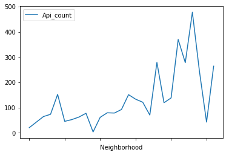

```python
df_cen_api.plot.line(x='Neighborhood',y='Api_count')
```

```python
df_cen_api_sorted = df_cen_api.sort_values(by=['Young_citizens'])
df_cen_api_sorted
```

|  | Neighborhood | Population | Male | Female | AGE0_4 | AGE5_11 | AGE12_14 | AGE15_17 | AGE18_24 | AGE25_34 | AGE35_44 | AGE45_64 | AGE65ovr | Young_citizens | Senior_citizens | Api_count |
| --- | --- | --- | --- | --- | --- | --- | --- | --- | --- | --- | --- | --- | --- | --- | --- | --- |
| 0 | York-Homeland | 482.6745 | 204.898 | 277.7765 | 17.2415 | 24.2415 | 5.4765 | 4.9530 | 83.334 | 40.3955 | 47.6775 | 129.8250 | 129.5300 | 223.3195 | 259.3550 | 20 |
| 1 | Rosebank | 394.0000 | 181.000 | 213.0000 | 19.0000 | 28.0000 | 9.0000 | 7.0000 | 32.000 | 72.0000 | 71.0000 | 122.0000 | 34.0000 | 238.0000 | 156.0000 | 42 |
| 2 | Bellona-Gittings | 599.0000 | 286.000 | 313.0000 | 38.0000 | 58.0000 | 20.0000 | 21.0000 | 32.000 | 39.0000 | 69.0000 | 191.0000 | 131.0000 | 277.0000 | 322.0000 | 64 |
| 3 | Lake Evesham | 543.0000 | 275.000 | 268.0000 | 39.0000 | 47.0000 | 12.0000 | 13.0000 | 80.000 | 72.0000 | 88.0000 | 142.0000 | 50.0000 | 351.0000 | 192.0000 | 73 |
| 4 | Wilson Park | 632.3202 | 283.463 | 348.8572 | 42.6508 | 54.0926 | 34.9881 | 28.5463 | 73.418 | 80.4180 | 63.8717 | 174.8122 | 79.5225 | 377.9855 | 254.3347 | 152 |
| 5 | Richnor Springs | 676.0000 | 288.000 | 388.0000 | 38.0000 | 70.0000 | 26.0000 | 27.0000 | 55.000 | 83.0000 | 80.0000 | 185.0000 | 112.0000 | 379.0000 | 297.0000 | 45 |
| 6 | Radnor-Winston | 684.0000 | 312.000 | 372.0000 | 39.0000 | 72.0000 | 21.0000 | 14.0000 | 94.000 | 44.0000 | 107.0000 | 193.0000 | 100.0000 | 391.0000 | 293.0000 | 52 |
| 7 | Belvedere | 720.0000 | 339.000 | 381.0000 | 39.0000 | 57.0000 | 24.0000 | 25.0000 | 47.000 | 114.0000 | 86.0000 | 242.0000 | 86.0000 | 392.0000 | 328.0000 | 62 |
| 8 | Cedarcroft | 726.0000 | 352.000 | 374.0000 | 54.0000 | 101.0000 | 26.0000 | 21.0000 | 31.000 | 35.0000 | 127.0000 | 236.0000 | 95.0000 | 395.0000 | 331.0000 | 77 |
| 9 | Villages Of Homeland | 562.3255 | 210.102 | 352.2235 | 18.7585 | 22.7585 | 3.5235 | 9.0470 | 181.666 | 88.6045 | 72.3225 | 125.1750 | 40.4700 | 396.6805 | 165.6450 | 3 |
| 10 | Kernewood | 726.0000 | 330.000 | 396.0000 | 46.0000 | 63.0000 | 35.0000 | 34.0000 | 66.000 | 76.0000 | 92.0000 | 219.0000 | 95.0000 | 412.0000 | 314.0000 | 61 |
| 11 | Evesham Park | 709.0000 | 334.000 | 375.0000 | 60.0000 | 58.0000 | 17.0000 | 10.0000 | 106.000 | 139.0000 | 103.0000 | 180.0000 | 36.0000 | 493.0000 | 216.0000 | 79 |
| 12 | Kenilworth Park | 1206.0000 | 546.000 | 660.0000 | 74.0000 | 98.0000 | 37.0000 | 51.0000 | 96.000 | 130.0000 | 152.0000 | 349.0000 | 219.0000 | 638.0000 | 568.0000 | 78 |
| 13 | Chinquapin Park | 1309.0000 | 584.000 | 725.0000 | 75.0000 | 93.0000 | 50.0000 | 47.0000 | 116.000 | 140.0000 | 170.0000 | 421.0000 | 197.0000 | 691.0000 | 618.0000 | 92 |
| 14 | Cameron Village | 1435.0000 | 642.000 | 793.0000 | 101.0000 | 127.0000 | 41.0000 | 67.0000 | 145.000 | 215.0000 | 169.0000 | 414.0000 | 156.0000 | 865.0000 | 570.0000 | 151 |
| 15 | Mid-Govans | 1465.0000 | 661.000 | 804.0000 | 103.0000 | 150.0000 | 66.0000 | 77.0000 | 153.000 | 188.0000 | 185.0000 | 390.0000 | 153.0000 | 922.0000 | 543.0000 | 133 |
| 16 | Ramblewood | 1705.0000 | 776.000 | 929.0000 | 83.0000 | 140.0000 | 82.0000 | 68.0000 | 180.000 | 215.0000 | 199.0000 | 570.0000 | 168.0000 | 967.0000 | 738.0000 | 121 |
| 17 | Woodbourne Heights | 1795.0000 | 781.000 | 1014.0000 | 119.0000 | 129.0000 | 62.0000 | 57.0000 | 242.000 | 256.0000 | 189.0000 | 551.0000 | 190.0000 | 1054.0000 | 741.0000 | 70 |
| 18 | Guilford | 2214.0000 | 1099.000 | 1115.0000 | 132.0000 | 218.0000 | 80.0000 | 79.0000 | 139.000 | 134.0000 | 327.0000 | 775.0000 | 330.0000 | 1109.0000 | 1105.0000 | 279 |
| 19 | Lake Walker | 2095.0000 | 955.000 | 1140.0000 | 174.0000 | 116.0000 | 40.0000 | 32.0000 | 288.000 | 393.0000 | 282.0000 | 513.0000 | 257.0000 | 1325.0000 | 770.0000 | 119 |
| 20 | Idlewood | 2676.0000 | 1200.000 | 1476.0000 | 173.0000 | 256.0000 | 114.0000 | 129.0000 | 253.000 | 401.0000 | 384.0000 | 754.0000 | 212.0000 | 1710.0000 | 966.0000 | 138 |
| 21 | Homeland | 3201.0000 | 1558.000 | 1643.0000 | 256.0000 | 311.0000 | 101.0000 | 108.0000 | 232.000 | 230.0000 | 502.0000 | 1028.0000 | 433.0000 | 1740.0000 | 1461.0000 | 370 |
| 22 | Glen Oaks | 2887.0000 | 1282.000 | 1605.0000 | 202.0000 | 284.0000 | 117.0000 | 125.0000 | 405.000 | 397.0000 | 357.0000 | 785.0000 | 215.0000 | 1887.0000 | 1000.0000 | 278 |
| 23 | Pen Lucy | 3078.0000 | 1383.000 | 1695.0000 | 245.0000 | 265.0000 | 117.0000 | 140.0000 | 331.000 | 455.0000 | 384.0000 | 826.0000 | 315.0000 | 1937.0000 | 1141.0000 | 478 |
| 24 | New Northwood | 4972.0000 | 2272.000 | 2700.0000 | 286.0000 | 313.0000 | 154.0000 | 231.0000 | 1013.000 | 611.0000 | 529.0000 | 1148.0000 | 687.0000 | 3137.0000 | 1835.0000 | 243 |
| 25 | Loyola/Notre Dame | 3208.0000 | 1195.000 | 2013.0000 | 2.0000 | 0.0000 | 2.0000 | 6.0000 | 3132.000 | 32.0000 | 3.0000 | 22.0000 | 9.0000 | 3177.0000 | 31.0000 | 42 |
| 26 | Loch Raven | 6163.0000 | 2557.000 | 3606.0000 | 347.0000 | 474.0000 | 191.0000 | 216.0000 | 653.000 | 914.0000 | 701.0000 | 1647.0000 | 1020.0000 | 3496.0000 | 2667.0000 | 264 |

```python
df_cen_api_sorted.Neighborhood
```

```
0            York-Homeland
1                 Rosebank
2         Bellona-Gittings
3             Lake Evesham
4              Wilson Park
5          Richnor Springs
6           Radnor-Winston
7                Belvedere
8               Cedarcroft
9     Villages Of Homeland
10               Kernewood
11            Evesham Park
12         Kenilworth Park
13         Chinquapin Park
14         Cameron Village
15              Mid-Govans
16              Ramblewood
17      Woodbourne Heights
18                Guilford
19             Lake Walker
20                Idlewood
21                Homeland
22               Glen Oaks
23                Pen Lucy
24           New Northwood
25       Loyola/Notre Dame
26              Loch Raven
Name: Neighborhood, dtype: object
```

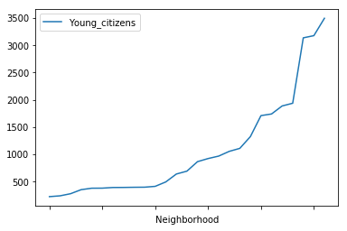

```python
df_cen_api_sorted.plot.line(x='Neighborhood',y='Young_citizens')
```

##### This graph shows that their is a relationship between Young age group baltimore citizens in particular neighborhood and number of service requests that are sent using Internet.

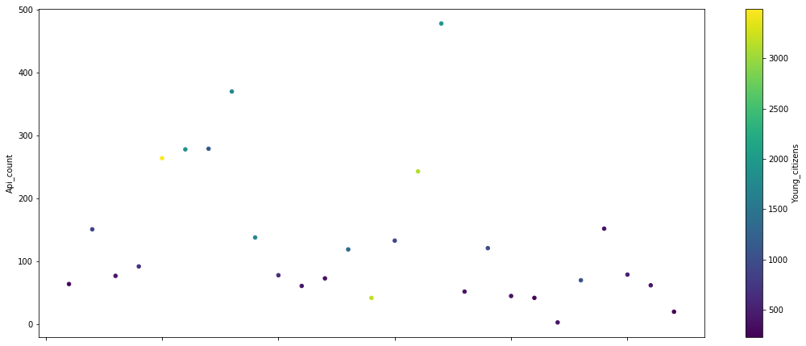

```python
df_cen_api_sorted.replace(neighborhood_num, inplace = True)
ax2  = df_cen_api_sorted.plot.scatter(x='Neighborhood',
                              y='Api_count',
                              c='Young_citizens',
                              colormap='viridis',
                              figsize=(18.5,7.5))
```

### 11. Exploring which neighborhoods in Balrimore are safe, moderate or dangerous based on crimes.

```python
df_crime = df_crime.groupby(["Neighborhood"]).size()
type(df_crime)
df_crime
```

```
Neighborhood
Abell                         31
Allendale                     67
Arcadia                       21
Arlington                    101
Armistead Gardens             60
Ashburton                     33
Baltimore Highlands          143
Barclay                       93
Barre Circle                  13
Bayview                       50
Beechfield                    54
Belair-Edison                380
Belair-Parkside               11
Belvedere                     10
Berea                        124
Better Waverly               126
Beverly Hills                  5
Biddle Street                 49
Bolton Hill                   62
Boyd-Booth                    25
Brewers Hill                  19
Bridgeview/Greenlawn          58
Broadway East                234
Broening Manor                52
Brooklyn                     315
Burleith-Leighton             18
Butcher's Hill                43
CARE                          55
Callaway-Garrison             34
Cameron Village               38
                            ...
Upper Fells Point             94
Upton                        322
Villages Of Homeland           2
Violetville                   62
Wakefield                     35
Walbrook                      79
Waltherson                    77
Washington Hill               78
```

[output cut: 8 more lines]

```
Wilhelm Park                   7
Wilson Park                   18
Winchester                    40
Windsor Hills                 28
Winston-Govans                37
Woodberry                     16
Woodbourne Heights            31
Woodbourne-McCabe             25
Woodmere                     109
Wrenlane                      17
Wyman Park                     7
Wyndhurst                      3
Yale Heights                  47
York-Homeland                 12
Length: 270, dtype: int64
```

```python
df_crime = pd.Series.to_frame(df_crime)
type(df_crime)
```

```
pandas.core.frame.DataFrame
```

```python
df_cen_api_crime = pd.merge(df_cen_api,df_crime, on='Neighborhood')
df_cen_api_crime = df_cen_api_crime.rename(columns={0:"Crimes"})
```

```python
df_cen_api_crime
```

|  | Neighborhood | Population | Male | Female | AGE0_4 | AGE5_11 | AGE12_14 | AGE15_17 | AGE18_24 | AGE25_34 | AGE35_44 | AGE45_64 | AGE65ovr | Young_citizens | Senior_citizens | Api_count | Crimes |
| --- | --- | --- | --- | --- | --- | --- | --- | --- | --- | --- | --- | --- | --- | --- | --- | --- | --- |
| 0 | York-Homeland | 482.6745 | 204.898 | 277.7765 | 17.2415 | 24.2415 | 5.4765 | 4.9530 | 83.334 | 40.3955 | 47.6775 | 129.8250 | 129.5300 | 223.3195 | 259.3550 | 20 | 12 |
| 1 | Rosebank | 394.0000 | 181.000 | 213.0000 | 19.0000 | 28.0000 | 9.0000 | 7.0000 | 32.000 | 72.0000 | 71.0000 | 122.0000 | 34.0000 | 238.0000 | 156.0000 | 42 | 9 |
| 2 | Lake Evesham | 543.0000 | 275.000 | 268.0000 | 39.0000 | 47.0000 | 12.0000 | 13.0000 | 80.000 | 72.0000 | 88.0000 | 142.0000 | 50.0000 | 351.0000 | 192.0000 | 73 | 4 |
| 3 | Wilson Park | 632.3202 | 283.463 | 348.8572 | 42.6508 | 54.0926 | 34.9881 | 28.5463 | 73.418 | 80.4180 | 63.8717 | 174.8122 | 79.5225 | 377.9855 | 254.3347 | 152 | 18 |
| 4 | Richnor Springs | 676.0000 | 288.000 | 388.0000 | 38.0000 | 70.0000 | 26.0000 | 27.0000 | 55.000 | 83.0000 | 80.0000 | 185.0000 | 112.0000 | 379.0000 | 297.0000 | 45 | 12 |
| 5 | Radnor-Winston | 684.0000 | 312.000 | 372.0000 | 39.0000 | 72.0000 | 21.0000 | 14.0000 | 94.000 | 44.0000 | 107.0000 | 193.0000 | 100.0000 | 391.0000 | 293.0000 | 52 | 9 |
| 6 | Belvedere | 720.0000 | 339.000 | 381.0000 | 39.0000 | 57.0000 | 24.0000 | 25.0000 | 47.000 | 114.0000 | 86.0000 | 242.0000 | 86.0000 | 392.0000 | 328.0000 | 62 | 10 |
| 7 | Cedarcroft | 726.0000 | 352.000 | 374.0000 | 54.0000 | 101.0000 | 26.0000 | 21.0000 | 31.000 | 35.0000 | 127.0000 | 236.0000 | 95.0000 | 395.0000 | 331.0000 | 77 | 3 |
| 8 | Villages Of Homeland | 562.3255 | 210.102 | 352.2235 | 18.7585 | 22.7585 | 3.5235 | 9.0470 | 181.666 | 88.6045 | 72.3225 | 125.1750 | 40.4700 | 396.6805 | 165.6450 | 3 | 2 |
| 9 | Kernewood | 726.0000 | 330.000 | 396.0000 | 46.0000 | 63.0000 | 35.0000 | 34.0000 | 66.000 | 76.0000 | 92.0000 | 219.0000 | 95.0000 | 412.0000 | 314.0000 | 61 | 17 |
| 10 | Evesham Park | 709.0000 | 334.000 | 375.0000 | 60.0000 | 58.0000 | 17.0000 | 10.0000 | 106.000 | 139.0000 | 103.0000 | 180.0000 | 36.0000 | 493.0000 | 216.0000 | 79 | 13 |
| 11 | Kenilworth Park | 1206.0000 | 546.000 | 660.0000 | 74.0000 | 98.0000 | 37.0000 | 51.0000 | 96.000 | 130.0000 | 152.0000 | 349.0000 | 219.0000 | 638.0000 | 568.0000 | 78 | 20 |
| 12 | Chinquapin Park | 1309.0000 | 584.000 | 725.0000 | 75.0000 | 93.0000 | 50.0000 | 47.0000 | 116.000 | 140.0000 | 170.0000 | 421.0000 | 197.0000 | 691.0000 | 618.0000 | 92 | 16 |
| 13 | Cameron Village | 1435.0000 | 642.000 | 793.0000 | 101.0000 | 127.0000 | 41.0000 | 67.0000 | 145.000 | 215.0000 | 169.0000 | 414.0000 | 156.0000 | 865.0000 | 570.0000 | 151 | 38 |
| 14 | Mid-Govans | 1465.0000 | 661.000 | 804.0000 | 103.0000 | 150.0000 | 66.0000 | 77.0000 | 153.000 | 188.0000 | 185.0000 | 390.0000 | 153.0000 | 922.0000 | 543.0000 | 133 | 44 |
| 15 | Ramblewood | 1705.0000 | 776.000 | 929.0000 | 83.0000 | 140.0000 | 82.0000 | 68.0000 | 180.000 | 215.0000 | 199.0000 | 570.0000 | 168.0000 | 967.0000 | 738.0000 | 121 | 12 |
| 16 | Woodbourne Heights | 1795.0000 | 781.000 | 1014.0000 | 119.0000 | 129.0000 | 62.0000 | 57.0000 | 242.000 | 256.0000 | 189.0000 | 551.0000 | 190.0000 | 1054.0000 | 741.0000 | 70 | 31 |
| 17 | Guilford | 2214.0000 | 1099.000 | 1115.0000 | 132.0000 | 218.0000 | 80.0000 | 79.0000 | 139.000 | 134.0000 | 327.0000 | 775.0000 | 330.0000 | 1109.0000 | 1105.0000 | 279 | 16 |
| 18 | Lake Walker | 2095.0000 | 955.000 | 1140.0000 | 174.0000 | 116.0000 | 40.0000 | 32.0000 | 288.000 | 393.0000 | 282.0000 | 513.0000 | 257.0000 | 1325.0000 | 770.0000 | 119 | 26 |
| 19 | Idlewood | 2676.0000 | 1200.000 | 1476.0000 | 173.0000 | 256.0000 | 114.0000 | 129.0000 | 253.000 | 401.0000 | 384.0000 | 754.0000 | 212.0000 | 1710.0000 | 966.0000 | 138 | 21 |
| 20 | Homeland | 3201.0000 | 1558.000 | 1643.0000 | 256.0000 | 311.0000 | 101.0000 | 108.0000 | 232.000 | 230.0000 | 502.0000 | 1028.0000 | 433.0000 | 1740.0000 | 1461.0000 | 370 | 9 |
| 21 | Glen Oaks | 2887.0000 | 1282.000 | 1605.0000 | 202.0000 | 284.0000 | 117.0000 | 125.0000 | 405.000 | 397.0000 | 357.0000 | 785.0000 | 215.0000 | 1887.0000 | 1000.0000 | 278 | 62 |
| 22 | Pen Lucy | 3078.0000 | 1383.000 | 1695.0000 | 245.0000 | 265.0000 | 117.0000 | 140.0000 | 331.000 | 455.0000 | 384.0000 | 826.0000 | 315.0000 | 1937.0000 | 1141.0000 | 478 | 70 |
| 23 | New Northwood | 4972.0000 | 2272.000 | 2700.0000 | 286.0000 | 313.0000 | 154.0000 | 231.0000 | 1013.000 | 611.0000 | 529.0000 | 1148.0000 | 687.0000 | 3137.0000 | 1835.0000 | 243 | 87 |
| 24 | Loyola/Notre Dame | 3208.0000 | 1195.000 | 2013.0000 | 2.0000 | 0.0000 | 2.0000 | 6.0000 | 3132.000 | 32.0000 | 3.0000 | 22.0000 | 9.0000 | 3177.0000 | 31.0000 | 42 | 3 |
| 25 | Loch Raven | 6163.0000 | 2557.000 | 3606.0000 | 347.0000 | 474.0000 | 191.0000 | 216.0000 | 653.000 | 914.0000 | 701.0000 | 1647.0000 | 1020.0000 | 3496.0000 | 2667.0000 | 264 | 85 |

```python
df_services = df_services.rename(columns={0:"Services"})
df_services
```

| Neighborhood | Services |
| --- | --- |
| Bellona-Gittings | 162 |
| Belvedere | 192 |
| Cameron Village | 648 |
| Cedarcroft | 200 |
| Chinquapin Park | 573 |
| Evesham Park | 247 |
| Glen Oaks | 1038 |
| Guilford | 1082 |
| Homeland | 1012 |
| Idlewood | 765 |
| Kenilworth Park | 431 |
| Kernewood | 382 |
| Lake Evesham | 182 |
| Lake Walker | 348 |
| Loch Raven | 1604 |
| Loyola/Notre Dame | 121 |
| Mid-Govans | 602 |
| New Northwood | 1337 |
| Pen Lucy | 1527 |
| Radnor-Winston | 198 |
| Ramblewood | 754 |
| Richnor Springs | 347 |
| Rosebank | 219 |
| Villages Of Homeland | 14 |
| Wilson Park | 490 |
| Woodbourne Heights | 370 |
| York-Homeland | 98 |

```python
df_cen_api_crime = pd.merge(df_cen_api_crime,df_services, on='Neighborhood')
```

```python
df_cen_api_crime
```

|  | Neighborhood | Population | Male | Female | AGE0_4 | AGE5_11 | AGE12_14 | AGE15_17 | AGE18_24 | AGE25_34 | AGE35_44 | AGE45_64 | AGE65ovr | Young_citizens | Senior_citizens | Api_count | Crimes | Services |
| --- | --- | --- | --- | --- | --- | --- | --- | --- | --- | --- | --- | --- | --- | --- | --- | --- | --- | --- |
| 0 | York-Homeland | 482.6745 | 204.898 | 277.7765 | 17.2415 | 24.2415 | 5.4765 | 4.9530 | 83.334 | 40.3955 | 47.6775 | 129.8250 | 129.5300 | 223.3195 | 259.3550 | 20 | 12 | 98 |
| 1 | Rosebank | 394.0000 | 181.000 | 213.0000 | 19.0000 | 28.0000 | 9.0000 | 7.0000 | 32.000 | 72.0000 | 71.0000 | 122.0000 | 34.0000 | 238.0000 | 156.0000 | 42 | 9 | 219 |
| 2 | Lake Evesham | 543.0000 | 275.000 | 268.0000 | 39.0000 | 47.0000 | 12.0000 | 13.0000 | 80.000 | 72.0000 | 88.0000 | 142.0000 | 50.0000 | 351.0000 | 192.0000 | 73 | 4 | 182 |
| 3 | Wilson Park | 632.3202 | 283.463 | 348.8572 | 42.6508 | 54.0926 | 34.9881 | 28.5463 | 73.418 | 80.4180 | 63.8717 | 174.8122 | 79.5225 | 377.9855 | 254.3347 | 152 | 18 | 490 |
| 4 | Richnor Springs | 676.0000 | 288.000 | 388.0000 | 38.0000 | 70.0000 | 26.0000 | 27.0000 | 55.000 | 83.0000 | 80.0000 | 185.0000 | 112.0000 | 379.0000 | 297.0000 | 45 | 12 | 347 |
| 5 | Radnor-Winston | 684.0000 | 312.000 | 372.0000 | 39.0000 | 72.0000 | 21.0000 | 14.0000 | 94.000 | 44.0000 | 107.0000 | 193.0000 | 100.0000 | 391.0000 | 293.0000 | 52 | 9 | 198 |
| 6 | Belvedere | 720.0000 | 339.000 | 381.0000 | 39.0000 | 57.0000 | 24.0000 | 25.0000 | 47.000 | 114.0000 | 86.0000 | 242.0000 | 86.0000 | 392.0000 | 328.0000 | 62 | 10 | 192 |
| 7 | Cedarcroft | 726.0000 | 352.000 | 374.0000 | 54.0000 | 101.0000 | 26.0000 | 21.0000 | 31.000 | 35.0000 | 127.0000 | 236.0000 | 95.0000 | 395.0000 | 331.0000 | 77 | 3 | 200 |
| 8 | Villages Of Homeland | 562.3255 | 210.102 | 352.2235 | 18.7585 | 22.7585 | 3.5235 | 9.0470 | 181.666 | 88.6045 | 72.3225 | 125.1750 | 40.4700 | 396.6805 | 165.6450 | 3 | 2 | 14 |
| 9 | Kernewood | 726.0000 | 330.000 | 396.0000 | 46.0000 | 63.0000 | 35.0000 | 34.0000 | 66.000 | 76.0000 | 92.0000 | 219.0000 | 95.0000 | 412.0000 | 314.0000 | 61 | 17 | 382 |
| 10 | Evesham Park | 709.0000 | 334.000 | 375.0000 | 60.0000 | 58.0000 | 17.0000 | 10.0000 | 106.000 | 139.0000 | 103.0000 | 180.0000 | 36.0000 | 493.0000 | 216.0000 | 79 | 13 | 247 |
| 11 | Kenilworth Park | 1206.0000 | 546.000 | 660.0000 | 74.0000 | 98.0000 | 37.0000 | 51.0000 | 96.000 | 130.0000 | 152.0000 | 349.0000 | 219.0000 | 638.0000 | 568.0000 | 78 | 20 | 431 |
| 12 | Chinquapin Park | 1309.0000 | 584.000 | 725.0000 | 75.0000 | 93.0000 | 50.0000 | 47.0000 | 116.000 | 140.0000 | 170.0000 | 421.0000 | 197.0000 | 691.0000 | 618.0000 | 92 | 16 | 573 |
| 13 | Cameron Village | 1435.0000 | 642.000 | 793.0000 | 101.0000 | 127.0000 | 41.0000 | 67.0000 | 145.000 | 215.0000 | 169.0000 | 414.0000 | 156.0000 | 865.0000 | 570.0000 | 151 | 38 | 648 |
| 14 | Mid-Govans | 1465.0000 | 661.000 | 804.0000 | 103.0000 | 150.0000 | 66.0000 | 77.0000 | 153.000 | 188.0000 | 185.0000 | 390.0000 | 153.0000 | 922.0000 | 543.0000 | 133 | 44 | 602 |
| 15 | Ramblewood | 1705.0000 | 776.000 | 929.0000 | 83.0000 | 140.0000 | 82.0000 | 68.0000 | 180.000 | 215.0000 | 199.0000 | 570.0000 | 168.0000 | 967.0000 | 738.0000 | 121 | 12 | 754 |
| 16 | Woodbourne Heights | 1795.0000 | 781.000 | 1014.0000 | 119.0000 | 129.0000 | 62.0000 | 57.0000 | 242.000 | 256.0000 | 189.0000 | 551.0000 | 190.0000 | 1054.0000 | 741.0000 | 70 | 31 | 370 |
| 17 | Guilford | 2214.0000 | 1099.000 | 1115.0000 | 132.0000 | 218.0000 | 80.0000 | 79.0000 | 139.000 | 134.0000 | 327.0000 | 775.0000 | 330.0000 | 1109.0000 | 1105.0000 | 279 | 16 | 1082 |
| 18 | Lake Walker | 2095.0000 | 955.000 | 1140.0000 | 174.0000 | 116.0000 | 40.0000 | 32.0000 | 288.000 | 393.0000 | 282.0000 | 513.0000 | 257.0000 | 1325.0000 | 770.0000 | 119 | 26 | 348 |
| 19 | Idlewood | 2676.0000 | 1200.000 | 1476.0000 | 173.0000 | 256.0000 | 114.0000 | 129.0000 | 253.000 | 401.0000 | 384.0000 | 754.0000 | 212.0000 | 1710.0000 | 966.0000 | 138 | 21 | 765 |
| 20 | Homeland | 3201.0000 | 1558.000 | 1643.0000 | 256.0000 | 311.0000 | 101.0000 | 108.0000 | 232.000 | 230.0000 | 502.0000 | 1028.0000 | 433.0000 | 1740.0000 | 1461.0000 | 370 | 9 | 1012 |
| 21 | Glen Oaks | 2887.0000 | 1282.000 | 1605.0000 | 202.0000 | 284.0000 | 117.0000 | 125.0000 | 405.000 | 397.0000 | 357.0000 | 785.0000 | 215.0000 | 1887.0000 | 1000.0000 | 278 | 62 | 1038 |
| 22 | Pen Lucy | 3078.0000 | 1383.000 | 1695.0000 | 245.0000 | 265.0000 | 117.0000 | 140.0000 | 331.000 | 455.0000 | 384.0000 | 826.0000 | 315.0000 | 1937.0000 | 1141.0000 | 478 | 70 | 1527 |
| 23 | New Northwood | 4972.0000 | 2272.000 | 2700.0000 | 286.0000 | 313.0000 | 154.0000 | 231.0000 | 1013.000 | 611.0000 | 529.0000 | 1148.0000 | 687.0000 | 3137.0000 | 1835.0000 | 243 | 87 | 1337 |
| 24 | Loyola/Notre Dame | 3208.0000 | 1195.000 | 2013.0000 | 2.0000 | 0.0000 | 2.0000 | 6.0000 | 3132.000 | 32.0000 | 3.0000 | 22.0000 | 9.0000 | 3177.0000 | 31.0000 | 42 | 3 | 121 |
| 25 | Loch Raven | 6163.0000 | 2557.000 | 3606.0000 | 347.0000 | 474.0000 | 191.0000 | 216.0000 | 653.000 | 914.0000 | 701.0000 | 1647.0000 | 1020.0000 | 3496.0000 | 2667.0000 | 264 | 85 | 1604 |

##### Ploting the bar graph that shows the neighborhoods which are safe, moderately safe and dangerous based on the crime rate at every neighborhood.

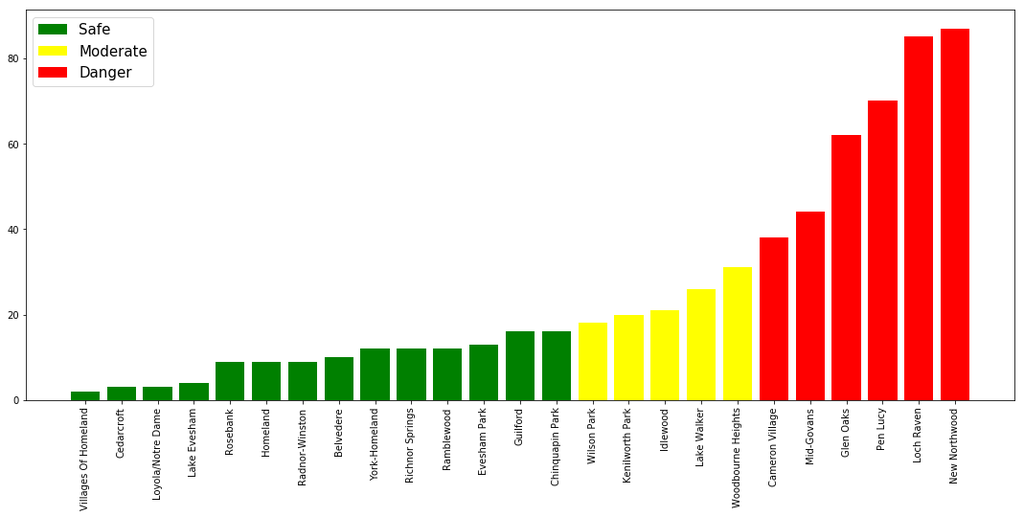

```python
import matplotlib.patches as mpatches

df_cen_api_crime = df_cen_api_crime.sort_values(by=['Crimes'])
x= df_cen_api_crime['Neighborhood']
y = df_cen_api_crime['Crimes']
filter1 = y<17
filter2 = y>17
filter3 = y > 35

Safety = ['Safe', 'Moderate', 'Danger']

plt.figure(figsize=(18.5,7.5))
plt.xticks(rotation=90)
plt.bar(x[filter1],y[filter1], color='green')
plt.bar(x[filter2],y[filter2], color='yellow')
plt.bar(x[filter3],y[filter3], color='red')
plt.legend(Safety, prop={'size':15})
plt.show()
#df_cen_api_crime.plot.bar(x='Neighborhood', y='Crimes', figsize=(18.5,7.5))
```

## 12. Exploring different types of methods in which the requests are received based on neighborhood

```python
api = df_service[ (df_service.MethodReceived == 'API')]
api = api.groupby('Neighborhood').size()
api = pd.Series.to_frame(api)
api_sorted = api.sort_values(by=['Neighborhood'])
api_sorted = api_sorted.rename(columns={0:"Api_count"})
type(api_sorted)
```

```
pandas.core.frame.DataFrame
```

```python
api_sorted
```

| Neighborhood | Api_count |
| --- | --- |
| Bellona-Gittings | 64 |
| Belvedere | 62 |
| Cameron Village | 151 |
| Cedarcroft | 77 |
| Chinquapin Park | 92 |
| Evesham Park | 79 |
| Glen Oaks | 278 |
| Guilford | 279 |
| Homeland | 370 |
| Idlewood | 138 |
| Kenilworth Park | 78 |
| Kernewood | 61 |
| Lake Evesham | 73 |
| Lake Walker | 119 |
| Loch Raven | 264 |
| Loyola/Notre Dame | 42 |
| Mid-Govans | 133 |
| New Northwood | 243 |
| Pen Lucy | 478 |
| Radnor-Winston | 52 |
| Ramblewood | 121 |
| Richnor Springs | 45 |
| Rosebank | 42 |
| Villages Of Homeland | 3 |
| Wilson Park | 152 |
| Woodbourne Heights | 70 |
| York-Homeland | 20 |

#### Only citizen belonging to Pen Lucy neighborhood has used Email to raise service request

```python
email = df_service[(df_service.MethodReceived == 'Email')]
email = email.groupby('Neighborhood').size()
email = pd.Series.to_frame(email)
email_sorted = email.sort_values(by=['Neighborhood'])
email_sorted = email_sorted.rename(columns={0:"Email_count"})
email_sorted
```

| Neighborhood | Email_count |
| --- | --- |
| Pen Lucy | 1 |

```python
Internal = df_service[ (df_service.MethodReceived == 'Internal')]
Internal = Internal.groupby('Neighborhood').size()
Internal = pd.Series.to_frame(Internal)
Internal_sorted = Internal.sort_values(by=['Neighborhood'])
Internal_sorted = Internal_sorted.rename(columns={0:"Internal_count"})
Internal_sorted
```

| Neighborhood | Internal_count |
| --- | --- |
| Bellona-Gittings | 6 |
| Belvedere | 16 |
| Cameron Village | 83 |
| Cedarcroft | 23 |
| Chinquapin Park | 82 |
| Evesham Park | 27 |
| Glen Oaks | 132 |
| Guilford | 188 |
| Homeland | 177 |
| Idlewood | 72 |
| Kenilworth Park | 69 |
| Kernewood | 60 |
| Lake Evesham | 18 |
| Lake Walker | 17 |
| Loch Raven | 111 |
| Loyola/Notre Dame | 8 |
| Mid-Govans | 56 |
| New Northwood | 167 |
| Pen Lucy | 115 |
| Radnor-Winston | 89 |
| Ramblewood | 93 |
| Richnor Springs | 38 |
| Rosebank | 64 |
| Wilson Park | 72 |
| Woodbourne Heights | 30 |
| York-Homeland | 29 |

```python
Phone = df_service[ (df_service.MethodReceived == 'Phone')]
Phone = Phone.groupby('Neighborhood').size()
Phone = pd.Series.to_frame(Phone)
Phone_sorted = Phone.sort_values(by=['Neighborhood'])
Phone_sorted = Phone_sorted.rename(columns={0:"Phone_count"})
Phone_sorted
```

| Neighborhood | Phone_count |
| --- | --- |
| Bellona-Gittings | 92 |
| Belvedere | 114 |
| Cameron Village | 414 |
| Cedarcroft | 100 |
| Chinquapin Park | 399 |
| Evesham Park | 141 |
| Glen Oaks | 628 |
| Guilford | 615 |
| Homeland | 465 |
| Idlewood | 554 |
| Kenilworth Park | 284 |
| Kernewood | 261 |
| Lake Evesham | 91 |
| Lake Walker | 212 |
| Loch Raven | 1229 |
| Loyola/Notre Dame | 71 |
| Mid-Govans | 413 |
| New Northwood | 927 |
| Pen Lucy | 933 |
| Radnor-Winston | 57 |
| Ramblewood | 540 |
| Richnor Springs | 264 |
| Rosebank | 113 |
| Villages Of Homeland | 11 |
| Wilson Park | 265 |
| Woodbourne Heights | 270 |
| York-Homeland | 49 |

```python
Other = df_service[ (df_service.MethodReceived == 'Other')]
Other = Other.groupby('Neighborhood').size()
Other = pd.Series.to_frame(Other)
Other_sorted = Other.sort_values(by=['Neighborhood'])
Other_sorted = Other_sorted.rename(columns={0:"Other_count"})
Other_sorted
```

| Neighborhood | Other_count |
| --- | --- |
| Idlewood | 1 |
| Wilson Park | 1 |

```python
df_service_merge = pd.merge(api_sorted,email_sorted, on='Neighborhood', how='outer')
df_service_merge = pd.merge(df_service_merge,Phone_sorted, on='Neighborhood', how='outer')
df_service_merge = pd.merge(df_service_merge,Other_sorted, on='Neighborhood', how='outer')
df_service_merge = pd.merge(df_service_merge,Internal_sorted, on='Neighborhood', how='outer')
df_service_merge = df_service_merge.fillna(0)
df_service_merge
```

| Neighborhood | Api_count | Email_count | Phone_count | Other_count | Internal_count |
| --- | --- | --- | --- | --- | --- |
| Bellona-Gittings | 64 | 0.0 | 92 | 0.0 | 6.0 |
| Belvedere | 62 | 0.0 | 114 | 0.0 | 16.0 |
| Cameron Village | 151 | 0.0 | 414 | 0.0 | 83.0 |
| Cedarcroft | 77 | 0.0 | 100 | 0.0 | 23.0 |
| Chinquapin Park | 92 | 0.0 | 399 | 0.0 | 82.0 |
| Evesham Park | 79 | 0.0 | 141 | 0.0 | 27.0 |
| Glen Oaks | 278 | 0.0 | 628 | 0.0 | 132.0 |
| Guilford | 279 | 0.0 | 615 | 0.0 | 188.0 |
| Homeland | 370 | 0.0 | 465 | 0.0 | 177.0 |
| Idlewood | 138 | 0.0 | 554 | 1.0 | 72.0 |
| Kenilworth Park | 78 | 0.0 | 284 | 0.0 | 69.0 |
| Kernewood | 61 | 0.0 | 261 | 0.0 | 60.0 |
| Lake Evesham | 73 | 0.0 | 91 | 0.0 | 18.0 |
| Lake Walker | 119 | 0.0 | 212 | 0.0 | 17.0 |
| Loch Raven | 264 | 0.0 | 1229 | 0.0 | 111.0 |
| Loyola/Notre Dame | 42 | 0.0 | 71 | 0.0 | 8.0 |
| Mid-Govans | 133 | 0.0 | 413 | 0.0 | 56.0 |
| New Northwood | 243 | 0.0 | 927 | 0.0 | 167.0 |
| Pen Lucy | 478 | 1.0 | 933 | 0.0 | 115.0 |
| Radnor-Winston | 52 | 0.0 | 57 | 0.0 | 89.0 |
| Ramblewood | 121 | 0.0 | 540 | 0.0 | 93.0 |
| Richnor Springs | 45 | 0.0 | 264 | 0.0 | 38.0 |
| Rosebank | 42 | 0.0 | 113 | 0.0 | 64.0 |
| Villages Of Homeland | 3 | 0.0 | 11 | 0.0 | 0.0 |
| Wilson Park | 152 | 0.0 | 265 | 1.0 | 72.0 |
| Woodbourne Heights | 70 | 0.0 | 270 | 0.0 | 30.0 |
| York-Homeland | 20 | 0.0 | 49 | 0.0 | 29.0 |

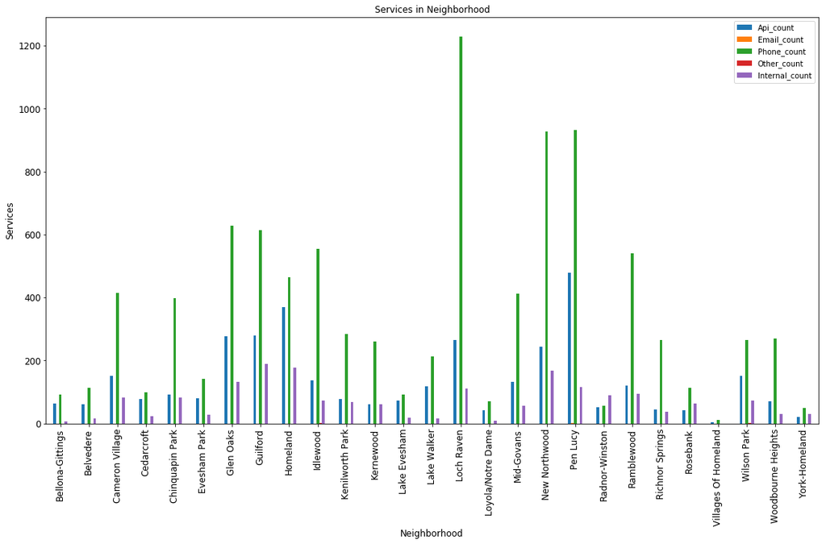

```python
ax = df_service_merge[['Api_count','Email_count','Phone_count','Other_count','Internal_count']].plot(kind='bar', title ="Services in Neighborhood", figsize=(18.5, 10), legend=True, fontsize=12)
ax.set_xlabel("Neighborhood", fontsize=12)
ax.set_ylabel("Services", fontsize=12)
plt.show()
```

## 13. District-wise distribution of topmost Crime Codes and their corresponding neighborhoods

```python
df_crimecode = df3.groupby('CrimeCode').size()
df_crimecode = pd.Series.to_frame(df_crimecode)
df_crimecode = df_crimecode.rename(columns={0: 'CountOfCrimeCode'})
df_crimecode = df_crimecode.sort_values(by=['CountOfCrimeCode'], ascending = False)
df_crimecode.head(5)
```

| CrimeCode | CountOfCrimeCode |
| --- | --- |
| 4E | 9257 |
| 6D | 7032 |
| 5A | 4719 |
| 7A | 3472 |
| 6G | 3292 |

```python
df_crime_district = df3[['CrimeCode','District']]
df_crime_district = df_crime_district[(df_crime_district['CrimeCode'] == '7A')]
df_crime_district.head()
```

|  | CrimeCode | District |
| --- | --- | --- |
| 73 | 7A | SOUTHWESTERN |
| 81 | 7A | WESTERN |
| 97 | 7A | CENTRAL |
| 100 | 7A | NORTHWESTERN |
| 131 | 7A | NORTHEASTERN |

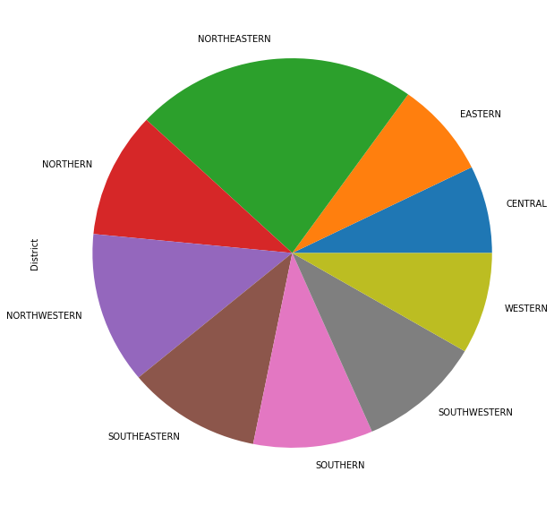

```python
fig, ax = plt.subplots(figsize=(10,10))
CrimeInDistrict = df_crime_district.groupby('District')['District'].count().plot.pie(subplots=True)
```

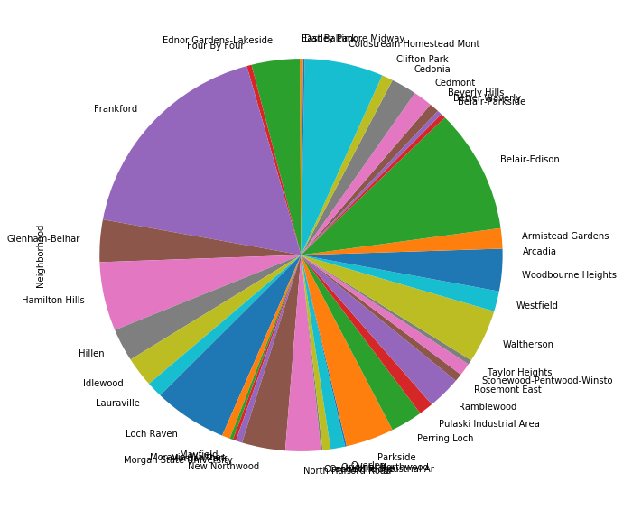

```python
df_crime_district_neighborhood = df3[['CrimeCode','District','Neighborhood']]
df_crime_district_neighborhood = df_crime_district_neighborhood[(df_crime_district_neighborhood['CrimeCode'] == '7A')]
df_crime_district_neighborhood = df_crime_district_neighborhood[(df_crime_district_neighborhood['District'] == 'NORTHEASTERN')]

fig, ax = plt.subplots(figsize=(10,10))
df_crime_district_neighborhood = df_crime_district_neighborhood.groupby('Neighborhood')['Neighborhood'].count().plot.pie(subplots=True)
```

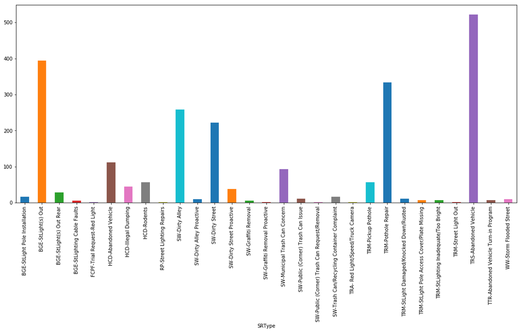

```python
df_service_method = df[['SRType','Neighborhood']]
df_service_method = df_service_method[(df_service_method['Neighborhood'] == 'Loch Raven')]
df_service_method = df_service_method.groupby('SRType').size()


df_service_method.plot.bar(figsize=(18.5,7.5))
```

#### Above graph shows that the Loch raven raises Abandoned Vehicles and Street lights out service requests the most.

## 14. Displaying direct relationship between the number of service requests and the crimes

```python
response = df_service.groupby(['Neighborhood'])['DaysRequired'].mean()
response = pd.Series.to_frame(response)
```

```python
df_cen_api_crime_days = df_cen_api_crime[['Neighborhood','Population','Young_citizens','Senior_citizens','Api_count','Crimes','Services']]
```

```python
df_cen_api_crime_days = pd.merge(df_cen_api_crime_days,response, on='Neighborhood')
```

```python
df_cen_api_crime_days.sort_values(by=['Crimes'])
```

|  | Neighborhood | Population | Young_citizens | Senior_citizens | Api_count | Crimes | Services | DaysRequired |
| --- | --- | --- | --- | --- | --- | --- | --- | --- |
| 0 | Villages Of Homeland | 562.3255 | 396.6805 | 165.6450 | 3 | 2 | 14 | 5.428571 |
| 1 | Cedarcroft | 726.0000 | 395.0000 | 331.0000 | 77 | 3 | 200 | 4.270000 |
| 2 | Loyola/Notre Dame | 3208.0000 | 3177.0000 | 31.0000 | 42 | 3 | 121 | 2.611570 |
| 3 | Lake Evesham | 543.0000 | 351.0000 | 192.0000 | 73 | 4 | 182 | 2.637363 |
| 4 | Rosebank | 394.0000 | 238.0000 | 156.0000 | 42 | 9 | 219 | 3.433790 |
| 5 | Homeland | 3201.0000 | 1740.0000 | 1461.0000 | 370 | 9 | 1012 | 3.064229 |
| 6 | Radnor-Winston | 684.0000 | 391.0000 | 293.0000 | 52 | 9 | 198 | 3.883838 |
| 7 | Belvedere | 720.0000 | 392.0000 | 328.0000 | 62 | 10 | 192 | 4.135417 |
| 8 | York-Homeland | 482.6745 | 223.3195 | 259.3550 | 20 | 12 | 98 | 2.857143 |
| 9 | Richnor Springs | 676.0000 | 379.0000 | 297.0000 | 45 | 12 | 347 | 4.544669 |
| 10 | Ramblewood | 1705.0000 | 967.0000 | 738.0000 | 121 | 12 | 754 | 3.359416 |
| 11 | Evesham Park | 709.0000 | 493.0000 | 216.0000 | 79 | 13 | 247 | 5.724696 |
| 13 | Chinquapin Park | 1309.0000 | 691.0000 | 618.0000 | 92 | 16 | 573 | 2.890052 |
| 12 | Guilford | 2214.0000 | 1109.0000 | 1105.0000 | 279 | 16 | 1082 | 2.342884 |
| 14 | Kernewood | 726.0000 | 412.0000 | 314.0000 | 61 | 17 | 382 | 3.191099 |
| 15 | Wilson Park | 632.3202 | 377.9855 | 254.3347 | 152 | 18 | 490 | 4.834694 |
| 16 | Kenilworth Park | 1206.0000 | 638.0000 | 568.0000 | 78 | 20 | 431 | 4.292343 |
| 17 | Idlewood | 2676.0000 | 1710.0000 | 966.0000 | 138 | 21 | 765 | 4.232680 |
| 18 | Lake Walker | 2095.0000 | 1325.0000 | 770.0000 | 119 | 26 | 348 | 5.465517 |
| 19 | Woodbourne Heights | 1795.0000 | 1054.0000 | 741.0000 | 70 | 31 | 370 | 4.651351 |
| 20 | Cameron Village | 1435.0000 | 865.0000 | 570.0000 | 151 | 38 | 648 | 4.066358 |
| 21 | Mid-Govans | 1465.0000 | 922.0000 | 543.0000 | 133 | 44 | 602 | 5.393688 |
| 22 | Glen Oaks | 2887.0000 | 1887.0000 | 1000.0000 | 278 | 62 | 1038 | 3.295761 |
| 23 | Pen Lucy | 3078.0000 | 1937.0000 | 1141.0000 | 478 | 70 | 1527 | 3.895219 |
| 24 | Loch Raven | 6163.0000 | 3496.0000 | 2667.0000 | 264 | 85 | 1604 | 3.997506 |
| 25 | New Northwood | 4972.0000 | 3137.0000 | 1835.0000 | 243 | 87 | 1337 | 3.724009 |

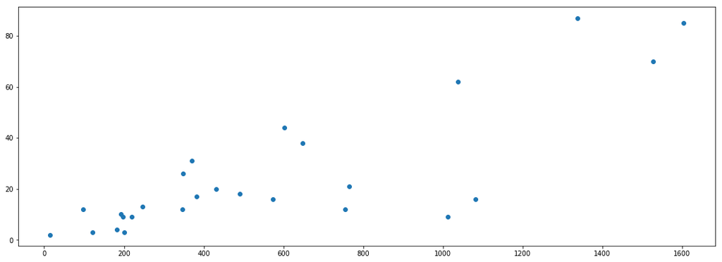

```python
plt.figure(figsize=(18.5,6.5))
plt.scatter(df_cen_api_crime_days['Services'], df_cen_api_crime_days['Crimes'])
plt.show()
```

From the above graph we can see that the Services requested are directly proportional to the crimes in a neighborhood. It tells us that as the crime in an area increases, the request raised for services increases.

## 15. Graphs we tried but could not find any relationship

> Since we found above that services are directly proportional to crime, we tried to find relation between crimes and the days required to resolve the service request. We were expecting a graph which shows that the particular neighborhood has more crimes as the services are not resolved on time. But the actual output did not show this expected result.

```python
df3.dropna()
```

|  | CrimeDate | CrimeCode | Location | Description | Weapon | District | Neighborhood |
| --- | --- | --- | --- | --- | --- | --- | --- |
| 0 | 1/1/2012 | 4A | 500 CHATEAU AV | AGG. ASSAULT | FIREARM | NORTHERN | Winston-Govans |
| 1 | 1/1/2012 | 4E | 2200 W NORTH AV | COMMON ASSAULT | HANDS | WESTERN | Coppin Heights/Ash-Co-Eas |
| 2 | 1/1/2012 | 4E | 0 S LINWOOD AV | COMMON ASSAULT | HANDS | SOUTHEASTERN | Patterson Park Neighborho |
| 6 | 1/1/2012 | 4E | 500 N GLOVER ST | COMMON ASSAULT | HANDS | SOUTHEASTERN | McElderry Park |
| 7 | 1/1/2012 | 4E | 4900 GOODNOW RD | COMMON ASSAULT | HANDS | NORTHEASTERN | Frankford |
| 11 | 1/1/2012 | 4C | 500 LONEYS LA | AGG. ASSAULT | OTHER | SOUTHEASTERN | Ellwood Park/Monument |
| 12 | 1/1/2012 | 4E | 1500 GORSUCH AV | COMMON ASSAULT | HANDS | NORTHEASTERN | Coldstream Homestead Mont |
| 14 | 1/1/2012 | 4C | 400 E BALTIMORE ST | AGG. ASSAULT | OTHER | CENTRAL | Downtown |
| 18 | 1/1/2012 | 4E | 300 N HIGHLAND AV | COMMON ASSAULT | HANDS | SOUTHEASTERN | Baltimore Highlands |
| 20 | 1/1/2012 | 4C | 2000 GRINNALDS AV | AGG. ASSAULT | OTHER | SOUTHWESTERN | Morrell Park |
| 21 | 1/1/2012 | 4E | 500 N ELLWOOD AV | COMMON ASSAULT | HANDS | SOUTHEASTERN | Ellwood Park/Monument |
| 27 | 1/1/2012 | 4B | 1900 E NORTH AV | AGG. ASSAULT | KNIFE | EASTERN | South Clifton Park |
| 28 | 1/1/2012 | 3CF | 1800 RUSSELL ST | ROBBERY - COMMERCIAL | FIREARM | SOUTHERN | Carroll - Camden Industri |
| 34 | 1/1/2012 | 4C | 0 E RANDALL ST | AGG. ASSAULT | OTHER | SOUTHERN | South Baltimore |
| 36 | 1/1/2012 | 4E | 1000 N WOLFE ST | COMMON ASSAULT | HANDS | EASTERN | Middle East |
| 37 | 1/1/2012 | 4E | 1000 N WOLFE ST | COMMON ASSAULT | HANDS | EASTERN | Middle East |
| 38 | 1/1/2012 | 4E | 2800 CARVER RD | COMMON ASSAULT | HANDS | SOUTHERN | Cherry Hill |
| 41 | 1/1/2012 | 9S | 500 OAKLAND AV | SHOOTING | FIREARM | NORTHERN | Wilson Park |
| 42 | 1/1/2012 | 4A | 500 OAKLAND AVE | AGG. ASSAULT | FIREARM | NORTHERN | Wilson Park |
| 45 | 1/1/2012 | 4E | 400 N ROSE ST | COMMON ASSAULT | HANDS | SOUTHEASTERN | McElderry Park |
| 46 | 1/1/2012 | 4C | 5700 PLAINFIELD AV | AGG. ASSAULT | OTHER | NORTHEASTERN | Frankford |
| 48 | 1/1/2012 | 4C | 2100 BAKER ST | AGG. ASSAULT | OTHER | WESTERN | Easterwood |
| 50 | 1/1/2012 | 4E | 2600 GREENMOUNT AV | COMMON ASSAULT | HANDS | NORTHERN | Harwood |
| 52 | 1/1/2012 | 4E | 1800 W LAFAYETTE AV | COMMON ASSAULT | HANDS | WESTERN | Sandtown-Winchester |
| 61 | 1/1/2012 | 3JF | 700 N FULTON AV | ROBBERY - RESIDENCE | FIREARM | WESTERN | Harlem Park |
| 64 | 1/1/2012 | 4C | 400 BOULDIN ST | AGG. ASSAULT | OTHER | SOUTHEASTERN | Ellwood Park/Monument |
| 65 | 1/1/2012 | 4E | 0 N GAY ST | COMMON ASSAULT | HANDS | CENTRAL | Downtown |
| 66 | 1/1/2012 | 4E | 4000 EIERMAN AV | COMMON ASSAULT | HANDS | NORTHEASTERN | Arcadia |
| 67 | 1/1/2012 | 4E | 1100 KEVIN RD | COMMON ASSAULT | HANDS | SOUTHWESTERN | Rognel Heights |
| 69 | 1/1/2012 | 4E | 800 BETHUNE RD | COMMON ASSAULT | HANDS | SOUTHERN | Cherry Hill |
| ... | ... | ... | ... | ... | ... | ... | ... |
| 49462 | 12/31/2012 | 3AF | 3700 ELLERSLIE AV | ROBBERY - STREET | FIREARM | NORTHERN | Waverly |
| 49463 | 12/31/2012 | 3AF | 3700 ELLERSLIE AV | ROBBERY - STREET | FIREARM | NORTHERN | Waverly |
| 49467 | 12/31/2012 | 4E | 2400 FREDERICK AV | COMMON ASSAULT | HANDS | SOUTHWESTERN | Shipley Hill |
| 49468 | 12/31/2012 | 3AK | 0 E HENRIETTA ST | ROBBERY - STREET | KNIFE | SOUTHERN | Federal Hill |
| 49474 | 12/31/2012 | 4E | 800 PARK AV | COMMON ASSAULT | HANDS | CENTRAL | Mount Vernon |
| 49475 | 12/31/2012 | 3CF | 4100 NORFOLK AV | ROBBERY - COMMERCIAL | FIREARM | NORTHWESTERN | West Forest Park |
| 49481 | 12/31/2012 | 1F | 2100 BRYANT AV | HOMICIDE | FIREARM | WESTERN | Mondawmin |
| 49483 | 12/31/2012 | 4E | 1300 HARLEM AV | COMMON ASSAULT | HANDS | WESTERN | Harlem Park |
| 49488 | 12/31/2012 | 4E | 200 N HOWARD ST | COMMON ASSAULT | HANDS | CENTRAL | Downtown |
| 49490 | 12/31/2012 | 4E | 1200 ROSSITER AV | COMMON ASSAULT | HANDS | NORTHEASTERN | New Northwood |
| 49491 | 12/31/2012 | 4C | 0 S ABINGTON AV | AGG. ASSAULT | OTHER | SOUTHWESTERN | Carroll-South Hilton |
| 49492 | 12/31/2012 | 4C | 2600 MARBOURNE AV | AGG. ASSAULT | OTHER | SOUTHERN | Lakeland |
| 49496 | 12/31/2012 | 4A | 5600 WINNER AV | AGG. ASSAULT | FIREARM | NORTHWESTERN | Glen |
| 49501 | 12/31/2012 | 4E | 300 S PULASKI ST | COMMON ASSAULT | HANDS | SOUTHWESTERN | Carrollton Ridge |
| 49503 | 12/31/2012 | 4E | 1200 LINWOOD AVE | COMMON ASSAULT | HANDS | EASTERN | Berea |
| 49504 | 12/31/2012 | 4E | 300 STOCKHOLM ST | COMMON ASSAULT | HANDS | SOUTHERN | Carroll - Camden Industri |
| 49505 | 12/31/2012 | 4E | 300 STOCKHOLM ST | COMMON ASSAULT | HANDS | SOUTHERN | Carroll - Camden Industri |
| 49509 | 12/31/2012 | 4E | 5100 GOODNOW RD | COMMON ASSAULT | HANDS | NORTHEASTERN | Frankford |
| 49519 | 12/31/2012 | 4C | 200 MONTFORD AVE | AGG. ASSAULT | OTHER | SOUTHEASTERN | Patterson Place |
| 49520 | 12/31/2012 | 4E | 4900 MIDWOOD AV | COMMON ASSAULT | HANDS | NORTHERN | Kenilworth Park |
| 49521 | 12/31/2012 | 4E | 900 DANTREY CT | COMMON ASSAULT | HANDS | SOUTHERN | Brooklyn |
| 49522 | 12/31/2012 | 4E | 900 DANTREY CT | COMMON ASSAULT | HANDS | SOUTHERN | Brooklyn |
| 49528 | 12/31/2012 | 4E | 2000 WILKINS AVE | COMMON ASSAULT | HANDS | SOUTHERN | Carrollton Ridge |
| 49535 | 12/31/2012 | 4E | 2000 WILKENS AV | COMMON ASSAULT | HANDS | SOUTHERN | Carrollton Ridge |
| 49539 | 12/31/2012 | 4E | 2800 HINSDALE DR | COMMON ASSAULT | HANDS | SOUTHERN | Lakeland |
| 49540 | 12/31/2012 | 4E | 3500 CHESTERFIELD AV | COMMON ASSAULT | HANDS | NORTHEASTERN | Belair-Edison |
| 49544 | 12/31/2012 | 3AF | 6000 NORTHWOOD DR | ROBBERY - STREET | FIREARM | NORTHERN | Evesham Park |
| 49545 | 12/31/2012 | 3AF | 3800 W FOREST PARK AV | ROBBERY - STREET | FIREARM | NORTHWESTERN | Central Forest Park |
| 49546 | 12/31/2012 | 4B | 1000 CATHEDRAL ST | AGG. ASSAULT | KNIFE | CENTRAL | Mid-Town Belvedere |
| 49551 | 12/31/2012 | 4E | 200 S DALLAS CT | COMMON ASSAULT | HANDS | SOUTHEASTERN | Perkins Homes |

17141 rows × 7 columns

Below graph is plotted against Days required to solve a service request and Crimes

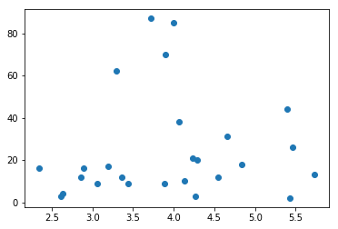

```python
#df_cen_api_crime_days.scatter(x='DaysRequired',y='Crimes')

plt.scatter(df_cen_api_crime_days['DaysRequired'], df_cen_api_crime_days['Crimes'])
plt.show()
```

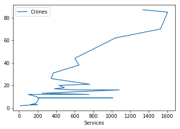

```python
df_cen_api_crime_days.plot(x='Services',y='Crimes')
```

### What were the insights gained from the data?

> Based on the scattered plot, we came to the conclusion that population and service requests are directly proportional. As the population increases, the number of service requests also increases.

> We tried to display the safety of some baltimore neighborhood based on the number of crimes occuring in each. The area whcih is most dangerous was New Northwood and lochraven whereas Villages of Homeland and Cedarcroft are the safest neighborhoods. We have ploted the bar graphs showing degree of safety for each neighborhood using different colors.

> The number of service requests were higher where large number of crimes occured. We can infer from this that since the crimes were more, there were lot of issues in the public services prvided or may be other way round.

> Auto theft, Common Assault, Burglary are some of the highly occuring crimes in Baltimore.

### Why is what we were trying to do valuable, and what did we learn?

> **The dataset that we are trying to plot is valuable in a sense that it gives the insight of the how safe is the area where we stay. Also, the population ditsribution based on age, gender etc can be understod. The relation between the age groups and method of raising requests can be interesting to know about what mode of communication is prefered by which age groups. Crime and service requests relationship will give us insights of how the number of service requests are impacted based on crimes occuring in any given neighborhood.**

### Why would someone else be interested in knowing what we learned? How might they use that knowledge?

**Someone staying in baltimore will be interested to know which is the safe neighbourhood and which is the dangerous so that the person can make the decision for accomodation. People will also be interested in our insights which shows how fast does the service is handled in which heighborhood of baltimore. The further study can be made to check the root causes of why the particular neighborhood takes longer to resolve service requests. This might help to know the scope of improvement in the performance.**